# internshala ML project

```python
import pandas as pd
import numpy as np
import matplotlib.pyplot as plt
import seaborn as sns
```

```python
data = pd.read_csv('Downloads/SnapDeal.csv')
data.head()
```

|  | Timestamp | age | Gender | Purchase_Frequency | Purchase_Categories | Personalized_Recommendation_Frequency | Browsing_Frequency | Product_Search_Method | Search_Result_Exploration | Customer_Reviews_Importance | ... | Review_Left | Review_Reliability | Review_Helpfulness | Personalized_Recommendation_Frequency | Recommendation_Helpfulness | Rating_Accuracy | Shopping_Satisfaction | Service_Appreciation | Improvement_Areas | transaction |
| --- | --- | --- | --- | --- | --- | --- | --- | --- | --- | --- | --- | --- | --- | --- | --- | --- | --- | --- | --- | --- | --- |
| 0 | 2023/06/07 11:06:40 PM GMT+5:30 | 59 | Others | Once a week | Beauty and Personal Care | Yes | Few times a month | others | Multiple pages | 4 | ... | Yes | Rarely | No | 1 | Yes | 3 | 3 | Customer service | User interface of app | 433348 |
| 1 | 2023/06/06 7:08:47 PM GMT+5:30 | 48 | Female | Once a month | Beauty and Personal Care;Clothing and Fashion;... | Sometimes | Rarely | categories | Multiple pages | 1 | ... | No | Never | Sometimes | 1 | No | 5 | 2 | . | . | 735054 |
| 2 | 2023/06/08 9:39:30 PM GMT+5:30 | 57 | Prefer not to say | Multiple times a week | Groceries and Gourmet Food | Sometimes | Rarely | Keyword | First page | 2 | ... | Yes | Rarely | No | 5 | Sometimes | 3 | 3 | Customer service | Product quality and accuracy | 119350 |
| 3 | 2023/06/07 9:22:24 PM GMT+5:30 | 30 | Others | Few times a month | Groceries and Gourmet Food;Beauty and Personal... | No | Few times a month | others | Multiple pages | 2 | ... | Yes | Rarely | Sometimes | 4 | Sometimes | 4 | 5 | Customer service | . | 180686 |
| 4 | 2023/06/06 7:21:26 PM GMT+5:30 | 51 | Female | Once a month | Groceries and Gourmet Food;Beauty and Personal... | No | Few times a month | Filter | First page | 5 | ... | Yes | Moderately | Sometimes | 1 | Yes | 3 | 1 | . | I don't have any problem with Amazon | 538184 |

5 rows × 24 columns

```python
# making a duplicate copy of data for data security
dt= data.copy()
dt.head()
```

|  | Timestamp | age | Gender | Purchase_Frequency | Purchase_Categories | Personalized_Recommendation_Frequency | Browsing_Frequency | Product_Search_Method | Search_Result_Exploration | Customer_Reviews_Importance | ... | Review_Left | Review_Reliability | Review_Helpfulness | Personalized_Recommendation_Frequency | Recommendation_Helpfulness | Rating_Accuracy | Shopping_Satisfaction | Service_Appreciation | Improvement_Areas | transaction |
| --- | --- | --- | --- | --- | --- | --- | --- | --- | --- | --- | --- | --- | --- | --- | --- | --- | --- | --- | --- | --- | --- |
| 0 | 2023/06/07 11:06:40 PM GMT+5:30 | 59 | Others | Once a week | Beauty and Personal Care | Yes | Few times a month | others | Multiple pages | 4 | ... | Yes | Rarely | No | 1 | Yes | 3 | 3 | Customer service | User interface of app | 433348 |
| 1 | 2023/06/06 7:08:47 PM GMT+5:30 | 48 | Female | Once a month | Beauty and Personal Care;Clothing and Fashion;... | Sometimes | Rarely | categories | Multiple pages | 1 | ... | No | Never | Sometimes | 1 | No | 5 | 2 | . | . | 735054 |
| 2 | 2023/06/08 9:39:30 PM GMT+5:30 | 57 | Prefer not to say | Multiple times a week | Groceries and Gourmet Food | Sometimes | Rarely | Keyword | First page | 2 | ... | Yes | Rarely | No | 5 | Sometimes | 3 | 3 | Customer service | Product quality and accuracy | 119350 |
| 3 | 2023/06/07 9:22:24 PM GMT+5:30 | 30 | Others | Few times a month | Groceries and Gourmet Food;Beauty and Personal... | No | Few times a month | others | Multiple pages | 2 | ... | Yes | Rarely | Sometimes | 4 | Sometimes | 4 | 5 | Customer service | . | 180686 |
| 4 | 2023/06/06 7:21:26 PM GMT+5:30 | 51 | Female | Once a month | Groceries and Gourmet Food;Beauty and Personal... | No | Few times a month | Filter | First page | 5 | ... | Yes | Moderately | Sometimes | 1 | Yes | 3 | 1 | . | I don't have any problem with Amazon | 538184 |

5 rows × 24 columns

```python
dt.size
```

```
19200
```

```python
dt.shape
```

```
(800, 24)
```

```python
dt.describe()
```

|  | age | Customer_Reviews_Importance | Personalized_Recommendation_Frequency | Rating_Accuracy | Shopping_Satisfaction | transaction |
| --- | --- | --- | --- | --- | --- | --- |
| count | 800.000000 | 800.000000 | 800.000000 | 800.00000 | 800.000000 | 800.00000 |
| mean | 36.053750 | 2.988750 | 2.911250 | 2.96375 | 2.988750 | 547442.01375 |
| std | 19.310087 | 1.400384 | 1.405647 | 1.42565 | 1.407515 | 255993.34801 |
| min | 3.000000 | 1.000000 | 1.000000 | 1.00000 | 1.000000 | 101141.00000 |
| 25% | 18.000000 | 2.000000 | 2.000000 | 2.00000 | 2.000000 | 322742.75000 |
| 50% | 37.000000 | 3.000000 | 3.000000 | 3.00000 | 3.000000 | 541612.50000 |
| 75% | 53.000000 | 4.000000 | 4.000000 | 4.00000 | 4.000000 | 765374.75000 |
| max | 67.000000 | 5.000000 | 5.000000 | 5.00000 | 5.000000 | 998820.00000 |

```python
dt.columns
```

```
Index(['Timestamp', 'age', 'Gender', 'Purchase_Frequency',
       'Purchase_Categories', 'Personalized_Recommendation_Frequency',
       'Browsing_Frequency', 'Product_Search_Method',
       'Search_Result_Exploration', 'Customer_Reviews_Importance',
       'Add_to_Cart_Browsing', 'Cart_Completion_Frequency',
       'Cart_Abandonment_Factors', 'Saveforlater_Frequency', 'Review_Left',
       'Review_Reliability', 'Review_Helpfulness',
       'Personalized_Recommendation_Frequency ', 'Recommendation_Helpfulness',
       'Rating_Accuracy ', 'Shopping_Satisfaction', 'Service_Appreciation',
       'Improvement_Areas', 'transaction'],
      dtype='object')
```

```python
dt.info()
```

```
<class 'pandas.core.frame.DataFrame'>
RangeIndex: 800 entries, 0 to 799
Data columns (total 24 columns):
 #   Column                                  Non-Null Count  Dtype
---  ------                                  --------------  -----
 0   Timestamp                               800 non-null    object
 1   age                                     800 non-null    int64
 2   Gender                                  800 non-null    object
 3   Purchase_Frequency                      800 non-null    object
 4   Purchase_Categories                     800 non-null    object
 5   Personalized_Recommendation_Frequency   800 non-null    object
 6   Browsing_Frequency                      800 non-null    object
 7   Product_Search_Method                   651 non-null    object
 8   Search_Result_Exploration               800 non-null    object
 9   Customer_Reviews_Importance             800 non-null    int64
```

[output cut: 16 more lines]

```python
dt.head()
```

|  | Timestamp | age | Gender | Purchase_Frequency | Purchase_Categories | Personalized_Recommendation_Frequency | Browsing_Frequency | Product_Search_Method | Search_Result_Exploration | Customer_Reviews_Importance | ... | Review_Left | Review_Reliability | Review_Helpfulness | Personalized_Recommendation_Frequency | Recommendation_Helpfulness | Rating_Accuracy | Shopping_Satisfaction | Service_Appreciation | Improvement_Areas | transaction |
| --- | --- | --- | --- | --- | --- | --- | --- | --- | --- | --- | --- | --- | --- | --- | --- | --- | --- | --- | --- | --- | --- |
| 0 | 2023/06/07 11:06:40 PM GMT+5:30 | 59 | Others | Once a week | Beauty and Personal Care | Yes | Few times a month | others | Multiple pages | 4 | ... | Yes | Rarely | No | 1 | Yes | 3 | 3 | Customer service | User interface of app | 433348 |
| 1 | 2023/06/06 7:08:47 PM GMT+5:30 | 48 | Female | Once a month | Beauty and Personal Care;Clothing and Fashion;... | Sometimes | Rarely | categories | Multiple pages | 1 | ... | No | Never | Sometimes | 1 | No | 5 | 2 | . | . | 735054 |
| 2 | 2023/06/08 9:39:30 PM GMT+5:30 | 57 | Prefer not to say | Multiple times a week | Groceries and Gourmet Food | Sometimes | Rarely | Keyword | First page | 2 | ... | Yes | Rarely | No | 5 | Sometimes | 3 | 3 | Customer service | Product quality and accuracy | 119350 |
| 3 | 2023/06/07 9:22:24 PM GMT+5:30 | 30 | Others | Few times a month | Groceries and Gourmet Food;Beauty and Personal... | No | Few times a month | others | Multiple pages | 2 | ... | Yes | Rarely | Sometimes | 4 | Sometimes | 4 | 5 | Customer service | . | 180686 |
| 4 | 2023/06/06 7:21:26 PM GMT+5:30 | 51 | Female | Once a month | Groceries and Gourmet Food;Beauty and Personal... | No | Few times a month | Filter | First page | 5 | ... | Yes | Moderately | Sometimes | 1 | Yes | 3 | 1 | . | I don't have any problem with Amazon | 538184 |

5 rows × 24 columns

### insuring there are no null values

```python
dt.isna().sum()
```

```
Timestamp                                   0
age                                         0
Gender                                      0
Purchase_Frequency                          0
Purchase_Categories                         0
Personalized_Recommendation_Frequency       0
Browsing_Frequency                          0
Product_Search_Method                     149
Search_Result_Exploration                   0
Customer_Reviews_Importance                 0
Add_to_Cart_Browsing                        0
Cart_Completion_Frequency                   0
Cart_Abandonment_Factors                    0
Saveforlater_Frequency                      0
Review_Left                                 0
Review_Reliability                          0
Review_Helpfulness                          0
Personalized_Recommendation_Frequency       0
Recommendation_Helpfulness                  0
Rating_Accuracy                             0
Shopping_Satisfaction                       0
Service_Appreciation                        0
Improvement_Areas                           0
transaction                                 0
dtype: int64
```

```python
dt[dt['Product_Search_Method'].isna()]
```

|  | Timestamp | age | Gender | Purchase_Frequency | Purchase_Categories | Personalized_Recommendation_Frequency | Browsing_Frequency | Product_Search_Method | Search_Result_Exploration | Customer_Reviews_Importance | ... | Review_Left | Review_Reliability | Review_Helpfulness | Personalized_Recommendation_Frequency | Recommendation_Helpfulness | Rating_Accuracy | Shopping_Satisfaction | Service_Appreciation | Improvement_Areas | transaction |
| --- | --- | --- | --- | --- | --- | --- | --- | --- | --- | --- | --- | --- | --- | --- | --- | --- | --- | --- | --- | --- | --- |
| 6 | 2023/06/06 7:40:53 PM GMT+5:30 | 10 | Male | Once a month | Groceries and Gourmet Food;Clothing and Fashio... | Sometimes | Few times a week | NaN | Multiple pages | 5 | ... | No | Rarely | Sometimes | 1 | Yes | 3 | 2 | Wide product selection | Nil | 445746 |
| 11 | 2023/06/09 9:35:57 AM GMT+5:30 | 15 | Others | Once a month | Clothing and Fashion;Home and Kitchen | Yes | Few times a month | NaN | First page | 3 | ... | No | Never | No | 4 | Yes | 5 | 3 | User-friendly website/app interface | better app interface and lower shipping charges | 252740 |
| 12 | 2023/06/09 9:33:35 AM GMT+5:30 | 7 | Others | Multiple times a week | others | Sometimes | Multiple times a day | NaN | First page | 3 | ... | Yes | Rarely | Sometimes | 5 | Yes | 5 | 5 | Quick delivery | Shipping speed and reliability | 785442 |
| 16 | 2023/06/08 5:27:22 PM GMT+5:30 | 31 | Female | Once a month | Groceries and Gourmet Food;Beauty and Personal... | Yes | Multiple times a day | NaN | Multiple pages | 1 | ... | Yes | Never | Yes | 3 | Sometimes | 4 | 4 | Competitive prices | . | 542620 |
| 28 | 2023/06/08 8:26:58 PM GMT+5:30 | 20 | Female | Few times a month | Clothing and Fashion;Home and Kitchen;others | Sometimes | Few times a month | NaN | Multiple pages | 1 | ... | No | Occasionally | No | 5 | Sometimes | 5 | 3 | Customer service | UI | 742772 |
| ... | ... | ... | ... | ... | ... | ... | ... | ... | ... | ... | ... | ... | ... | ... | ... | ... | ... | ... | ... | ... | ... |
| 770 | 2023/06/07 1:25:26 PM GMT+5:30 | 40 | Prefer not to say | Once a week | Groceries and Gourmet Food;Home and Kitchen | Yes | Multiple times a day | NaN | Multiple pages | 4 | ... | Yes | Moderately | Sometimes | 4 | Yes | 3 | 2 | Wide product selection | User interface of app | 837191 |
| 776 | 2023/06/06 7:18:01 PM GMT+5:30 | 17 | Male | Less than once a month | Groceries and Gourmet Food;Clothing and Fashion | No | Few times a month | NaN | Multiple pages | 1 | ... | Yes | Rarely | Sometimes | 1 | Sometimes | 5 | 3 | Wide product selection | Scrolling option would be much better than goi... | 890872 |
| 780 | 2023/06/07 6:30:43 PM GMT+5:30 | 16 | Prefer not to say | Once a month | Groceries and Gourmet Food | Yes | Few times a week | NaN | Multiple pages | 2 | ... | Yes | Never | No | 5 | Yes | 2 | 2 | Customer service | I have no problem with Amazon yet. But others ... | 834597 |
| 789 | 2023/06/08 3:29:26 AM GMT+5:30 | 47 | Female | Less than once a month | Clothing and Fashion | Yes | Multiple times a day | NaN | First page | 5 | ... | Yes | Heavily | Sometimes | 2 | No | 4 | 4 | User-friendly website/app interface | I don't have any problem with Amazon | 421355 |
| 796 | 2023/06/09 7:22:11 PM GMT+5:30 | 56 | Female | Multiple times a week | Beauty and Personal Care;Clothing and Fashion;... | Yes | Rarely | NaN | Multiple pages | 3 | ... | Yes | Occasionally | Yes | 4 | Sometimes | 4 | 4 | Customer service | . | 524319 |

149 rows × 24 columns

```python
dt=dt.dropna()
```

```python
dt.isna().sum()
```

```
Timestamp                                 0
age                                       0
Gender                                    0
Purchase_Frequency                        0
Purchase_Categories                       0
Personalized_Recommendation_Frequency     0
Browsing_Frequency                        0
Product_Search_Method                     0
Search_Result_Exploration                 0
Customer_Reviews_Importance               0
Add_to_Cart_Browsing                      0
Cart_Completion_Frequency                 0
Cart_Abandonment_Factors                  0
Saveforlater_Frequency                    0
Review_Left                               0
Review_Reliability                        0
Review_Helpfulness                        0
Personalized_Recommendation_Frequency     0
Recommendation_Helpfulness                0
Rating_Accuracy                           0
Shopping_Satisfaction                     0
Service_Appreciation                      0
Improvement_Areas                         0
transaction                               0
dtype: int64
```

### insuring there are no duplicate values

```python
dt.duplicated().sum()
```

```
np.int64(0)
```

```python
dt[dt.duplicated()]
```

|  | Timestamp | age | Gender | Purchase_Frequency | Purchase_Categories | Personalized_Recommendation_Frequency | Browsing_Frequency | Product_Search_Method | Search_Result_Exploration | Customer_Reviews_Importance | ... | Review_Left | Review_Reliability | Review_Helpfulness | Personalized_Recommendation_Frequency | Recommendation_Helpfulness | Rating_Accuracy | Shopping_Satisfaction | Service_Appreciation | Improvement_Areas | transaction |
| --- | --- | --- | --- | --- | --- | --- | --- | --- | --- | --- | --- | --- | --- | --- | --- | --- | --- | --- | --- | --- | --- |

0 rows × 24 columns

**there are no duplicate values in the data**

```python
# changing the column names so that it can be used easly
for i in dt.columns:
    dt = dt.rename(columns={i:i.lower()})
```

```python
dt.head()
```

|  | timestamp | age | gender | purchase_frequency | purchase_categories | personalized_recommendation_frequency | browsing_frequency | product_search_method | search_result_exploration | customer_reviews_importance | ... | review_left | review_reliability | review_helpfulness | personalized_recommendation_frequency | recommendation_helpfulness | rating_accuracy | shopping_satisfaction | service_appreciation | improvement_areas | transaction |
| --- | --- | --- | --- | --- | --- | --- | --- | --- | --- | --- | --- | --- | --- | --- | --- | --- | --- | --- | --- | --- | --- |
| 0 | 2023/06/07 11:06:40 PM GMT+5:30 | 59 | Others | Once a week | Beauty and Personal Care | Yes | Few times a month | others | Multiple pages | 4 | ... | Yes | Rarely | No | 1 | Yes | 3 | 3 | Customer service | User interface of app | 433348 |
| 1 | 2023/06/06 7:08:47 PM GMT+5:30 | 48 | Female | Once a month | Beauty and Personal Care;Clothing and Fashion;... | Sometimes | Rarely | categories | Multiple pages | 1 | ... | No | Never | Sometimes | 1 | No | 5 | 2 | . | . | 735054 |
| 2 | 2023/06/08 9:39:30 PM GMT+5:30 | 57 | Prefer not to say | Multiple times a week | Groceries and Gourmet Food | Sometimes | Rarely | Keyword | First page | 2 | ... | Yes | Rarely | No | 5 | Sometimes | 3 | 3 | Customer service | Product quality and accuracy | 119350 |
| 3 | 2023/06/07 9:22:24 PM GMT+5:30 | 30 | Others | Few times a month | Groceries and Gourmet Food;Beauty and Personal... | No | Few times a month | others | Multiple pages | 2 | ... | Yes | Rarely | Sometimes | 4 | Sometimes | 4 | 5 | Customer service | . | 180686 |
| 4 | 2023/06/06 7:21:26 PM GMT+5:30 | 51 | Female | Once a month | Groceries and Gourmet Food;Beauty and Personal... | No | Few times a month | Filter | First page | 5 | ... | Yes | Moderately | Sometimes | 1 | Yes | 3 | 1 | . | I don't have any problem with Amazon | 538184 |

5 rows × 24 columns

**separating timestamp into data and time columns**

```python
dt[["date", "time", "am_pm", "time_zone"]] = dt['timestamp'].str.split(' ',expand=True)
```

```python
dt.head()
```

|  | timestamp | age | gender | purchase_frequency | purchase_categories | personalized_recommendation_frequency | browsing_frequency | product_search_method | search_result_exploration | customer_reviews_importance | ... | recommendation_helpfulness | rating_accuracy | shopping_satisfaction | service_appreciation | improvement_areas | transaction | date | time | am_pm | time_zone |
| --- | --- | --- | --- | --- | --- | --- | --- | --- | --- | --- | --- | --- | --- | --- | --- | --- | --- | --- | --- | --- | --- |
| 0 | 2023/06/07 11:06:40 PM GMT+5:30 | 59 | Others | Once a week | Beauty and Personal Care | Yes | Few times a month | others | Multiple pages | 4 | ... | Yes | 3 | 3 | Customer service | User interface of app | 433348 | 2023/06/07 | 11:06:40 | PM | GMT+5:30 |
| 1 | 2023/06/06 7:08:47 PM GMT+5:30 | 48 | Female | Once a month | Beauty and Personal Care;Clothing and Fashion;... | Sometimes | Rarely | categories | Multiple pages | 1 | ... | No | 5 | 2 | . | . | 735054 | 2023/06/06 | 7:08:47 | PM | GMT+5:30 |
| 2 | 2023/06/08 9:39:30 PM GMT+5:30 | 57 | Prefer not to say | Multiple times a week | Groceries and Gourmet Food | Sometimes | Rarely | Keyword | First page | 2 | ... | Sometimes | 3 | 3 | Customer service | Product quality and accuracy | 119350 | 2023/06/08 | 9:39:30 | PM | GMT+5:30 |
| 3 | 2023/06/07 9:22:24 PM GMT+5:30 | 30 | Others | Few times a month | Groceries and Gourmet Food;Beauty and Personal... | No | Few times a month | others | Multiple pages | 2 | ... | Sometimes | 4 | 5 | Customer service | . | 180686 | 2023/06/07 | 9:22:24 | PM | GMT+5:30 |
| 4 | 2023/06/06 7:21:26 PM GMT+5:30 | 51 | Female | Once a month | Groceries and Gourmet Food;Beauty and Personal... | No | Few times a month | Filter | First page | 5 | ... | Yes | 3 | 1 | . | I don't have any problem with Amazon | 538184 | 2023/06/06 | 7:21:26 | PM | GMT+5:30 |

5 rows × 28 columns

```python
dt=dt.drop(['timestamp','time_zone'],axis=1)
```

```python
dt
```

|  | age | gender | purchase_frequency | purchase_categories | personalized_recommendation_frequency | browsing_frequency | product_search_method | search_result_exploration | customer_reviews_importance | add_to_cart_browsing | ... | personalized_recommendation_frequency | recommendation_helpfulness | rating_accuracy | shopping_satisfaction | service_appreciation | improvement_areas | transaction | date | time | am_pm |
| --- | --- | --- | --- | --- | --- | --- | --- | --- | --- | --- | --- | --- | --- | --- | --- | --- | --- | --- | --- | --- | --- |
| 0 | 59 | Others | Once a week | Beauty and Personal Care | Yes | Few times a month | others | Multiple pages | 4 | Yes | ... | 1 | Yes | 3 | 3 | Customer service | User interface of app | 433348 | 2023/06/07 | 11:06:40 | PM |
| 1 | 48 | Female | Once a month | Beauty and Personal Care;Clothing and Fashion;... | Sometimes | Rarely | categories | Multiple pages | 1 | Maybe | ... | 1 | No | 5 | 2 | . | . | 735054 | 2023/06/06 | 7:08:47 | PM |
| 2 | 57 | Prefer not to say | Multiple times a week | Groceries and Gourmet Food | Sometimes | Rarely | Keyword | First page | 2 | Yes | ... | 5 | Sometimes | 3 | 3 | Customer service | Product quality and accuracy | 119350 | 2023/06/08 | 9:39:30 | PM |
| 3 | 30 | Others | Few times a month | Groceries and Gourmet Food;Beauty and Personal... | No | Few times a month | others | Multiple pages | 2 | Maybe | ... | 4 | Sometimes | 4 | 5 | Customer service | . | 180686 | 2023/06/07 | 9:22:24 | PM |
| 4 | 51 | Female | Once a month | Groceries and Gourmet Food;Beauty and Personal... | No | Few times a month | Filter | First page | 5 | No | ... | 1 | Yes | 3 | 1 | . | I don't have any problem with Amazon | 538184 | 2023/06/06 | 7:21:26 | PM |
| ... | ... | ... | ... | ... | ... | ... | ... | ... | ... | ... | ... | ... | ... | ... | ... | ... | ... | ... | ... | ... | ... |
| 794 | 19 | Male | Multiple times a week | Groceries and Gourmet Food;Clothing and Fashio... | Sometimes | Few times a month | Keyword | Multiple pages | 3 | Yes | ... | 4 | Sometimes | 4 | 1 | Competitive prices | Add more familiar brands to the list | 312813 | 2023/06/07 | 12:13:39 | PM |
| 795 | 60 | Male | Less than once a month | Groceries and Gourmet Food;Beauty and Personal... | Sometimes | Multiple times a day | others | First page | 5 | Yes | ... | 3 | Sometimes | 4 | 2 | Customer service | Nothing | 526649 | 2023/06/11 | 2:07:39 | PM |
| 797 | 48 | Female | Multiple times a week | Groceries and Gourmet Food | Sometimes | Multiple times a day | others | Multiple pages | 5 | Yes | ... | 5 | Yes | 2 | 4 | Wide product selection | Product quality and accuracy | 637762 | 2023/06/12 | 3:47:01 | PM |
| 798 | 40 | Male | Multiple times a week | Groceries and Gourmet Food;Beauty and Personal... | No | Few times a month | Keyword | Multiple pages | 2 | No | ... | 4 | Sometimes | 4 | 3 | Quick delivery | Nil | 290410 | 2023/06/06 | 6:51:13 | PM |
| 799 | 67 | Others | Multiple times a week | Clothing and Fashion;Home and Kitchen | Sometimes | Multiple times a day | Keyword | First page | 2 | Yes | ... | 1 | Sometimes | 3 | 2 | All the above | Irrelevant product suggestions | 867703 | 2023/06/09 | 10:26:51 | AM |

651 rows × 26 columns

```python
dt['date'] = pd.to_datetime(dt['date'], format='%Y/%m/%d')
```

```python
dt['time'] = pd.to_datetime(dt['time'] + ' ' + dt['am_pm'], format='%I:%M:%S %p').dt.time
```

```python
dt.head()
```

|  | age | gender | purchase_frequency | purchase_categories | personalized_recommendation_frequency | browsing_frequency | product_search_method | search_result_exploration | customer_reviews_importance | add_to_cart_browsing | ... | personalized_recommendation_frequency | recommendation_helpfulness | rating_accuracy | shopping_satisfaction | service_appreciation | improvement_areas | transaction | date | time | am_pm |
| --- | --- | --- | --- | --- | --- | --- | --- | --- | --- | --- | --- | --- | --- | --- | --- | --- | --- | --- | --- | --- | --- |
| 0 | 59 | Others | Once a week | Beauty and Personal Care | Yes | Few times a month | others | Multiple pages | 4 | Yes | ... | 1 | Yes | 3 | 3 | Customer service | User interface of app | 433348 | 2023-06-07 | 23:06:40 | PM |
| 1 | 48 | Female | Once a month | Beauty and Personal Care;Clothing and Fashion;... | Sometimes | Rarely | categories | Multiple pages | 1 | Maybe | ... | 1 | No | 5 | 2 | . | . | 735054 | 2023-06-06 | 19:08:47 | PM |
| 2 | 57 | Prefer not to say | Multiple times a week | Groceries and Gourmet Food | Sometimes | Rarely | Keyword | First page | 2 | Yes | ... | 5 | Sometimes | 3 | 3 | Customer service | Product quality and accuracy | 119350 | 2023-06-08 | 21:39:30 | PM |
| 3 | 30 | Others | Few times a month | Groceries and Gourmet Food;Beauty and Personal... | No | Few times a month | others | Multiple pages | 2 | Maybe | ... | 4 | Sometimes | 4 | 5 | Customer service | . | 180686 | 2023-06-07 | 21:22:24 | PM |
| 4 | 51 | Female | Once a month | Groceries and Gourmet Food;Beauty and Personal... | No | Few times a month | Filter | First page | 5 | No | ... | 1 | Yes | 3 | 1 | . | I don't have any problem with Amazon | 538184 | 2023-06-06 | 19:21:26 | PM |

5 rows × 26 columns

```python
dt.info()
```

```
<class 'pandas.core.frame.DataFrame'>
Index: 651 entries, 0 to 799
Data columns (total 26 columns):
 #   Column                                  Non-Null Count  Dtype
---  ------                                  --------------  -----
 0   age                                     651 non-null    int64
 1   gender                                  651 non-null    object
 2   purchase_frequency                      651 non-null    object
 3   purchase_categories                     651 non-null    object
 4   personalized_recommendation_frequency   651 non-null    object
 5   browsing_frequency                      651 non-null    object
 6   product_search_method                   651 non-null    object
 7   search_result_exploration               651 non-null    object
 8   customer_reviews_importance             651 non-null    int64
 9   add_to_cart_browsing                    651 non-null    object
```

[output cut: 18 more lines]

### Standardize categorical/numerical entries (e.g., frequency levels, gender, recommendation responses)

### gender

```python
dt.gender
```

```
0                 Others
1                 Female
2      Prefer not to say
3                 Others
4                 Female
             ...
794                 Male
795                 Male
797               Female
798                 Male
799               Others
Name: gender, Length: 651, dtype: object
```

```python
dt.gender.unique()
```

```
array(['Others', 'Female', 'Prefer not to say', 'Male'], dtype=object)
```

```python
dt['gender'] = (dt['gender'].astype('category').cat.set_categories(['Others', 'Female', 'Prefer not to say', 'Male']).cat.codes.astype(str))
```

### purchase_frequency

```python
dt.purchase_frequency.unique()
```

```
array(['Once a week', 'Once a month', 'Multiple times a week',
       'Few times a month', 'Less than once a month'], dtype=object)
```

```python
dt['purchase_frequency'] = (dt['purchase_frequency'].astype('category').cat.set_categories(['Less than once a month',
    'Once a month',
    'Few times a month',
    'Once a week',
    'Multiple times a week']).cat.codes.astype(str))
```

### browsing_frequency

```python
dt.browsing_frequency.unique()
```

```
array(['Few times a month', 'Rarely', 'Few times a week',
       'Multiple times a day'], dtype=object)
```

```python
dt['browsing_frequency'] = (dt['browsing_frequency'].astype('category').cat.set_categories(['Few times a month', 'Rarely', 'Few times a week',
       'Multiple times a day']).cat.codes.astype(str))
```

```python
dt.head()
```

|  | age | gender | purchase_frequency | purchase_categories | personalized_recommendation_frequency | browsing_frequency | product_search_method | search_result_exploration | customer_reviews_importance | add_to_cart_browsing | ... | personalized_recommendation_frequency | recommendation_helpfulness | rating_accuracy | shopping_satisfaction | service_appreciation | improvement_areas | transaction | date | time | am_pm |
| --- | --- | --- | --- | --- | --- | --- | --- | --- | --- | --- | --- | --- | --- | --- | --- | --- | --- | --- | --- | --- | --- |
| 0 | 59 | 0 | 3 | Beauty and Personal Care | Yes | 0 | others | Multiple pages | 4 | Yes | ... | 1 | Yes | 3 | 3 | Customer service | User interface of app | 433348 | 2023-06-07 | 23:06:40 | PM |
| 1 | 48 | 1 | 1 | Beauty and Personal Care;Clothing and Fashion;... | Sometimes | 1 | categories | Multiple pages | 1 | Maybe | ... | 1 | No | 5 | 2 | . | . | 735054 | 2023-06-06 | 19:08:47 | PM |
| 2 | 57 | 2 | 4 | Groceries and Gourmet Food | Sometimes | 1 | Keyword | First page | 2 | Yes | ... | 5 | Sometimes | 3 | 3 | Customer service | Product quality and accuracy | 119350 | 2023-06-08 | 21:39:30 | PM |
| 3 | 30 | 0 | 2 | Groceries and Gourmet Food;Beauty and Personal... | No | 0 | others | Multiple pages | 2 | Maybe | ... | 4 | Sometimes | 4 | 5 | Customer service | . | 180686 | 2023-06-07 | 21:22:24 | PM |
| 4 | 51 | 1 | 1 | Groceries and Gourmet Food;Beauty and Personal... | No | 0 | Filter | First page | 5 | No | ... | 1 | Yes | 3 | 1 | . | I don't have any problem with Amazon | 538184 | 2023-06-06 | 19:21:26 | PM |

5 rows × 26 columns

## ● Handle missing values and inconsistent formats in Product_Search_Method and other

**there are some rows as . showing their values**

```python
dt = dt.replace('.', np.nan)
```

```python
dt.isna().sum()
```

```
age                                        0
gender                                     0
purchase_frequency                         0
purchase_categories                        0
personalized_recommendation_frequency      0
browsing_frequency                         0
product_search_method                      0
search_result_exploration                  0
customer_reviews_importance                0
add_to_cart_browsing                       0
cart_completion_frequency                  0
cart_abandonment_factors                   0
saveforlater_frequency                     0
review_left                                0
review_reliability                         0
review_helpfulness                         0
personalized_recommendation_frequency      0
recommendation_helpfulness                 0
rating_accuracy                            0
shopping_satisfaction                      0
service_appreciation                      70
improvement_areas                         33
transaction                                0
date                                       0
time                                       0
am_pm                                      0
dtype: int64
```

```python
df = dt.dropna()
df
```

|  | age | gender | purchase_frequency | purchase_categories | personalized_recommendation_frequency | browsing_frequency | product_search_method | search_result_exploration | customer_reviews_importance | add_to_cart_browsing | ... | personalized_recommendation_frequency | recommendation_helpfulness | rating_accuracy | shopping_satisfaction | service_appreciation | improvement_areas | transaction | date | time | am_pm |
| --- | --- | --- | --- | --- | --- | --- | --- | --- | --- | --- | --- | --- | --- | --- | --- | --- | --- | --- | --- | --- | --- |
| 0 | 59 | 0 | 3 | Beauty and Personal Care | Yes | 0 | others | Multiple pages | 4 | Yes | ... | 1 | Yes | 3 | 3 | Customer service | User interface of app | 433348 | 2023-06-07 | 23:06:40 | PM |
| 2 | 57 | 2 | 4 | Groceries and Gourmet Food | Sometimes | 1 | Keyword | First page | 2 | Yes | ... | 5 | Sometimes | 3 | 3 | Customer service | Product quality and accuracy | 119350 | 2023-06-08 | 21:39:30 | PM |
| 5 | 33 | 1 | 4 | Groceries and Gourmet Food;Beauty and Personal... | Yes | 0 | categories | Multiple pages | 3 | No | ... | 5 | Sometimes | 4 | 4 | Customer service | Customer service responsiveness | 116480 | 2023-06-04 | 23:27:53 | PM |
| 7 | 30 | 3 | 3 | Groceries and Gourmet Food;Beauty and Personal... | No | 0 | categories | First page | 2 | Yes | ... | 1 | Sometimes | 5 | 2 | Wide product selection | No problems with Amazon | 372797 | 2023-06-06 | 17:16:58 | PM |
| 8 | 8 | 1 | 1 | Clothing and Fashion | Sometimes | 2 | Filter | First page | 3 | Yes | ... | 5 | Sometimes | 1 | 2 | All the above | No problems with Amazon | 571022 | 2023-06-08 | 21:39:55 | PM |
| ... | ... | ... | ... | ... | ... | ... | ... | ... | ... | ... | ... | ... | ... | ... | ... | ... | ... | ... | ... | ... | ... |
| 794 | 19 | 3 | 4 | Groceries and Gourmet Food;Clothing and Fashio... | Sometimes | 0 | Keyword | Multiple pages | 3 | Yes | ... | 4 | Sometimes | 4 | 1 | Competitive prices | Add more familiar brands to the list | 312813 | 2023-06-07 | 12:13:39 | PM |
| 795 | 60 | 3 | 0 | Groceries and Gourmet Food;Beauty and Personal... | Sometimes | 3 | others | First page | 5 | Yes | ... | 3 | Sometimes | 4 | 2 | Customer service | Nothing | 526649 | 2023-06-11 | 14:07:39 | PM |
| 797 | 48 | 1 | 4 | Groceries and Gourmet Food | Sometimes | 3 | others | Multiple pages | 5 | Yes | ... | 5 | Yes | 2 | 4 | Wide product selection | Product quality and accuracy | 637762 | 2023-06-12 | 15:47:01 | PM |
| 798 | 40 | 3 | 4 | Groceries and Gourmet Food;Beauty and Personal... | No | 0 | Keyword | Multiple pages | 2 | No | ... | 4 | Sometimes | 4 | 3 | Quick delivery | Nil | 290410 | 2023-06-06 | 18:51:13 | PM |
| 799 | 67 | 0 | 4 | Clothing and Fashion;Home and Kitchen | Sometimes | 3 | Keyword | First page | 2 | Yes | ... | 1 | Sometimes | 3 | 2 | All the above | Irrelevant product suggestions | 867703 | 2023-06-09 | 10:26:51 | AM |

553 rows × 26 columns

```python
df.isna().sum()
```

```
age                                       0
gender                                    0
purchase_frequency                        0
purchase_categories                       0
personalized_recommendation_frequency     0
browsing_frequency                        0
product_search_method                     0
search_result_exploration                 0
customer_reviews_importance               0
add_to_cart_browsing                      0
cart_completion_frequency                 0
cart_abandonment_factors                  0
saveforlater_frequency                    0
review_left                               0
review_reliability                        0
review_helpfulness                        0
personalized_recommendation_frequency     0
recommendation_helpfulness                0
rating_accuracy                           0
shopping_satisfaction                     0
service_appreciation                      0
improvement_areas                         0
transaction                               0
date                                      0
time                                      0
am_pm                                     0
dtype: int64
```

### Rename duplicate or misformatted columns (e.g., remove trailing spaces in Rating_Accuracy ).

```python
df.columns
```

```
Index(['age', 'gender', 'purchase_frequency', 'purchase_categories',
       'personalized_recommendation_frequency', 'browsing_frequency',
       'product_search_method', 'search_result_exploration',
       'customer_reviews_importance', 'add_to_cart_browsing',
       'cart_completion_frequency', 'cart_abandonment_factors',
       'saveforlater_frequency', 'review_left', 'review_reliability',
       'review_helpfulness', 'personalized_recommendation_frequency ',
       'recommendation_helpfulness', 'rating_accuracy ',
       'shopping_satisfaction', 'service_appreciation', 'improvement_areas',
       'transaction', 'date', 'time', 'am_pm'],
      dtype='object')
```

```python
df['rating_accuracy ']
```

```
0      3
2      3
5      4
7      5
8      1
      ..
794    4
795    4
797    2
798    4
799    3
Name: rating_accuracy , Length: 553, dtype: int64
```

```python
for i in dt.columns:
    df=df.rename(columns={i:i.strip()})
```

```python
df.columns
```

```
Index(['age', 'gender', 'purchase_frequency', 'purchase_categories',
       'personalized_recommendation_frequency', 'browsing_frequency',
       'product_search_method', 'search_result_exploration',
       'customer_reviews_importance', 'add_to_cart_browsing',
       'cart_completion_frequency', 'cart_abandonment_factors',
       'saveforlater_frequency', 'review_left', 'review_reliability',
       'review_helpfulness', 'personalized_recommendation_frequency',
       'recommendation_helpfulness', 'rating_accuracy',
       'shopping_satisfaction', 'service_appreciation', 'improvement_areas',
       'transaction', 'date', 'time', 'am_pm'],
      dtype='object')
```

```python
df.columns.duplicated()
```

```
array([False, False, False, False, False, False, False, False, False,
       False, False, False, False, False, False, False,  True, False,
       False, False, False, False, False, False, False, False])
```

```python
df = df.loc[:, ~df.columns.duplicated(keep='last')]
df.columns.duplicated()
```

```
array([False, False, False, False, False, False, False, False, False,
       False, False, False, False, False, False, False, False, False,
       False, False, False, False, False, False, False])
```

## Convert numerical rating columns (e.g., Customer_Reviews_Importance, Shopping_Satisfaction) to appropriate numeric types for analysis.

```python
df.info()
```

```
<class 'pandas.core.frame.DataFrame'>
Index: 553 entries, 0 to 799
Data columns (total 25 columns):
 #   Column                                 Non-Null Count  Dtype
---  ------                                 --------------  -----
 0   age                                    553 non-null    int64
 1   gender                                 553 non-null    object
 2   purchase_frequency                     553 non-null    object
 3   purchase_categories                    553 non-null    object
 4   browsing_frequency                     553 non-null    object
 5   product_search_method                  553 non-null    object
 6   search_result_exploration              553 non-null    object
 7   customer_reviews_importance            553 non-null    int64
 8   add_to_cart_browsing                   553 non-null    object
 9   cart_completion_frequency              553 non-null    object
```

[output cut: 17 more lines]

```python
df.shopping_satisfaction
```

```
0      3
2      3
5      4
7      2
8      2
      ..
794    1
795    2
797    4
798    3
799    2
Name: shopping_satisfaction, Length: 553, dtype: int64
```

```python
df.head()
```

|  | age | gender | purchase_frequency | purchase_categories | browsing_frequency | product_search_method | search_result_exploration | customer_reviews_importance | add_to_cart_browsing | cart_completion_frequency | ... | personalized_recommendation_frequency | recommendation_helpfulness | rating_accuracy | shopping_satisfaction | service_appreciation | improvement_areas | transaction | date | time | am_pm |
| --- | --- | --- | --- | --- | --- | --- | --- | --- | --- | --- | --- | --- | --- | --- | --- | --- | --- | --- | --- | --- | --- |
| 0 | 59 | 0 | 3 | Beauty and Personal Care | 0 | others | Multiple pages | 4 | Yes | Rarely | ... | 1 | Yes | 3 | 3 | Customer service | User interface of app | 433348 | 2023-06-07 | 23:06:40 | PM |
| 2 | 57 | 2 | 4 | Groceries and Gourmet Food | 1 | Keyword | First page | 2 | Yes | Never | ... | 5 | Sometimes | 3 | 3 | Customer service | Product quality and accuracy | 119350 | 2023-06-08 | 21:39:30 | PM |
| 5 | 33 | 1 | 4 | Groceries and Gourmet Food;Beauty and Personal... | 0 | categories | Multiple pages | 3 | No | Often | ... | 5 | Sometimes | 4 | 4 | Customer service | Customer service responsiveness | 116480 | 2023-06-04 | 23:27:53 | PM |
| 7 | 30 | 3 | 3 | Groceries and Gourmet Food;Beauty and Personal... | 0 | categories | First page | 2 | Yes | Always | ... | 1 | Sometimes | 5 | 2 | Wide product selection | No problems with Amazon | 372797 | 2023-06-06 | 17:16:58 | PM |
| 8 | 8 | 1 | 1 | Clothing and Fashion | 2 | Filter | First page | 3 | Yes | Rarely | ... | 5 | Sometimes | 1 | 2 | All the above | No problems with Amazon | 571022 | 2023-06-08 | 21:39:55 | PM |

5 rows × 25 columns

**all the numeric columns are already in numeric format**

# Task 2: Descriptive Behavior Analysis

## ● Summarize customer demographics (age, gender distribution).

### age

```python
df.age
```

```
0      59
2      57
5      33
7      30
8       8
       ..
794    19
795    60
797    48
798    40
799    67
Name: age, Length: 553, dtype: int64
```

```python
df.age.describe()
```

```
count    553.000000
mean      35.900542
std       19.453565
min        3.000000
25%       18.000000
50%       36.000000
75%       53.000000
max       67.000000
Name: age, dtype: float64
```

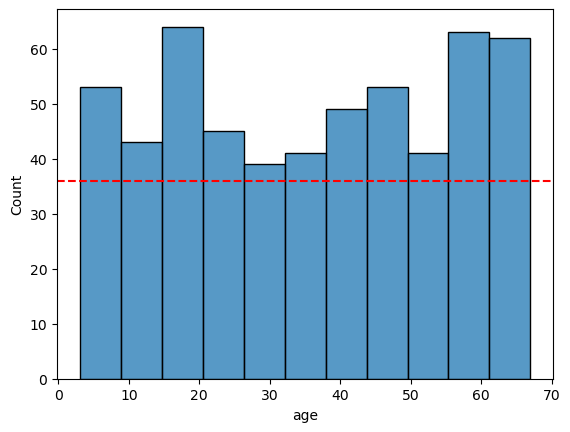

```python
sns.histplot(data=df, x='age')
plt.axhline(y=df['age'].mean(),color='red',ls='--',label='mean')
```

```python
def outliers(col:str):
    quant25=dt[col].quantile(.25)
    quant75=dt[col].quantile(.75)
    iqr=quant75-quant25
    print('IQR',iqr)
    upper_limit= quant75 + 1.5*iqr
    lower_limit= quant25 - 1.5*iqr
    print('upper_limit',upper_limit)
    print('lower_limit',lower_limit)
    upper_mask=dt[col]>upper_limit
    lower_mask=dt[col]<lower_limit
    print('NO. of outliers in',col,' = ',len(dt[upper_mask|lower_mask]))
    sns.boxplot(data=dt,x=col)
    plt.show()
    return dt[upper_mask|lower_mask]
    sns.histplot(data=dt,x=col)
    plt.show()
```

```
IQR 35.0
upper_limit 105.5
lower_limit -34.5
NO. of outliers in age  =  0
```

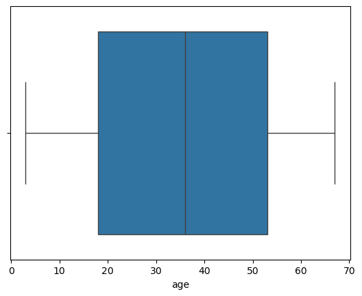

|  | age | gender | purchase_frequency | purchase_categories | personalized_recommendation_frequency | browsing_frequency | product_search_method | search_result_exploration | customer_reviews_importance | add_to_cart_browsing | ... | personalized_recommendation_frequency | recommendation_helpfulness | rating_accuracy | shopping_satisfaction | service_appreciation | improvement_areas | transaction | date | time | am_pm |
| --- | --- | --- | --- | --- | --- | --- | --- | --- | --- | --- | --- | --- | --- | --- | --- | --- | --- | --- | --- | --- | --- |

0 rows × 26 columns

```python
outliers('age')
```

### gender

```python
df.gender.unique()
```

```
array(['0', '2', '1', '3'], dtype=object)
```

### take ['Others', 'Female', 'Prefer not to say', 'Male'] as 0,1,2,3

```python
df.gender
```

```
0      0
2      2
5      1
7      3
8      1
      ..
794    3
795    3
797    1
798    3
799    0
Name: gender, Length: 553, dtype: object
```

```python
df.gender.value_counts()
```

```
gender
3    150
0    137
2    133
1    133
Name: count, dtype: int64
```

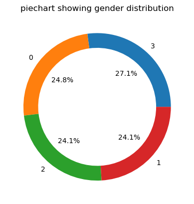

```python
plt.pie(df.gender.value_counts(),labels=df.gender.value_counts().index,autopct='%0.1f%%',wedgeprops=dict(width=0.2))
plt.title('piechart showing gender distribution');
```

## ● Analyze overall purchase frequency and most popular product categories.

### purchase_frequency

```python
df.purchase_frequency
```

```
0      3
2      4
5      4
7      3
8      1
      ..
794    4
795    0
797    4
798    4
799    4
Name: purchase_frequency, Length: 553, dtype: object
```

**['Less than once a month','Once a month','Few times a month','Once a week', 'Multiple times a week'] as 0,1,2,3,4**

```python
df.purchase_frequency.value_counts()
```

```
purchase_frequency
4    120
0    119
3    110
2    108
1     96
Name: count, dtype: int64
```

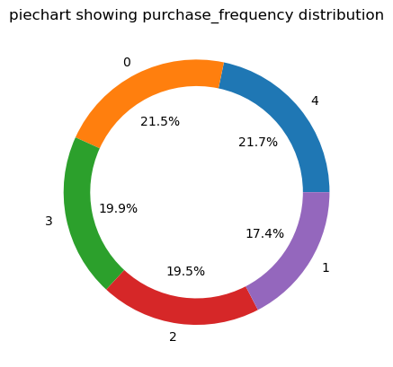

```python
plt.pie(df.purchase_frequency.value_counts(),labels=df.purchase_frequency.value_counts().index,autopct='%0.1f%%',wedgeprops=dict(width=0.2))
plt.title('piechart showing purchase_frequency distribution');
```

## purchase_categories

```python
df.purchase_categories
```

```
0                               Beauty and Personal Care
2                             Groceries and Gourmet Food
5      Groceries and Gourmet Food;Beauty and Personal...
7      Groceries and Gourmet Food;Beauty and Personal...
8                                   Clothing and Fashion
                             ...
794    Groceries and Gourmet Food;Clothing and Fashio...
795    Groceries and Gourmet Food;Beauty and Personal...
797                           Groceries and Gourmet Food
798    Groceries and Gourmet Food;Beauty and Personal...
799                Clothing and Fashion;Home and Kitchen
Name: purchase_categories, Length: 553, dtype: object
```

```python
df.purchase_categories.value_counts()
```

```
purchase_categories
Clothing and Fashion;Home and Kitchen                                                               26
Groceries and Gourmet Food;Clothing and Fashion;Home and Kitchen;others                             25
Beauty and Personal Care;Clothing and Fashion;others                                                25
Clothing and Fashion                                                                                23
Beauty and Personal Care;Clothing and Fashion                                                       23
Beauty and Personal Care;Clothing and Fashion;Home and Kitchen;others                               22
Groceries and Gourmet Food;Beauty and Personal Care;Clothing and Fashion;Home and Kitchen           22
Clothing and Fashion;others                                                                         22
Groceries and Gourmet Food;Beauty and Personal Care                                                 21
Groceries and Gourmet Food;Beauty and Personal Care;Clothing and Fashion                            21
Clothing and Fashion;Home and Kitchen;others                                                        21
Groceries and Gourmet Food                                                                          20
others                                                                                              20
Beauty and Personal Care;Clothing and Fashion;Home and Kitchen                                      20
Groceries and Gourmet Food;Beauty and Personal Care;Clothing and Fashion;Home and Kitchen;others    20
Beauty and Personal Care;others                                                                     19
Beauty and Personal Care;Home and Kitchen;others                                                    19
Groceries and Gourmet Food;Clothing and Fashion;others                                              18
Groceries and Gourmet Food;Home and Kitchen;others                                                  18
Groceries and Gourmet Food;Beauty and Personal Care;Home and Kitchen                                17
Groceries and Gourmet Food;Beauty and Personal Care;others                                          17
Home and Kitchen                                                                                    16
Groceries and Gourmet Food;Beauty and Personal Care;Clothing and Fashion;others                     16
Groceries and Gourmet Food;Clothing and Fashion;Home and Kitchen                                    16
Groceries and Gourmet Food;Home and Kitchen                                                         15
Home and Kitchen;others                                                                             15
Groceries and Gourmet Food;Clothing and Fashion                                                     14
Beauty and Personal Care;Home and Kitchen                                                           12
Beauty and Personal Care                                                                            10
Name: count, dtype: int64
```

```python
df[['purchase_categories']]
```

|  | purchase_categories |
| --- | --- |
| 0 | Beauty and Personal Care |
| 2 | Groceries and Gourmet Food |
| 5 | Groceries and Gourmet Food;Beauty and Personal... |
| 7 | Groceries and Gourmet Food;Beauty and Personal... |
| 8 | Clothing and Fashion |
| ... | ... |
| 794 | Groceries and Gourmet Food;Clothing and Fashio... |
| 795 | Groceries and Gourmet Food;Beauty and Personal... |
| 797 | Groceries and Gourmet Food |
| 798 | Groceries and Gourmet Food;Beauty and Personal... |
| 799 | Clothing and Fashion;Home and Kitchen |

553 rows × 1 columns

```python
product_count = df['purchase_categories'].str.split(';').explode().value_counts().reset_index()
product_count
```

|  | purchase_categories | count |
| --- | --- | --- |
| 0 | Clothing and Fashion | 334 |
| 1 | Beauty and Personal Care | 284 |
| 2 | Home and Kitchen | 284 |
| 3 | others | 277 |
| 4 | Groceries and Gourmet Food | 260 |

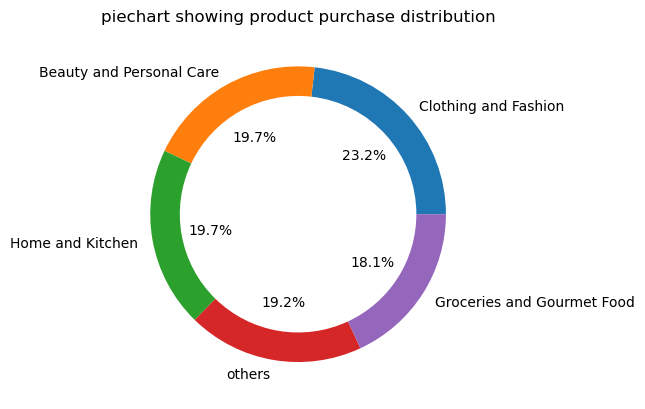

```python
plt.pie(df['purchase_categories'].str.split(';').explode().value_counts(),labels=df['purchase_categories'].str.split(';').explode().value_counts().index,autopct='%0.1f%%',wedgeprops=dict(width=0.2))
plt.title('piechart showing product purchase distribution');
```

**clothing and fashion are most purchased category followed by beauty and personal care**

## Identify top browsing methods and most common cart abandonment factors

```python
df.head()
```

|  | age | gender | purchase_frequency | purchase_categories | browsing_frequency | product_search_method | search_result_exploration | customer_reviews_importance | add_to_cart_browsing | cart_completion_frequency | ... | personalized_recommendation_frequency | recommendation_helpfulness | rating_accuracy | shopping_satisfaction | service_appreciation | improvement_areas | transaction | date | time | am_pm |
| --- | --- | --- | --- | --- | --- | --- | --- | --- | --- | --- | --- | --- | --- | --- | --- | --- | --- | --- | --- | --- | --- |
| 0 | 59 | 0 | 3 | Beauty and Personal Care | 0 | others | Multiple pages | 4 | Yes | Rarely | ... | 1 | Yes | 3 | 3 | Customer service | User interface of app | 433348 | 2023-06-07 | 23:06:40 | PM |
| 2 | 57 | 2 | 4 | Groceries and Gourmet Food | 1 | Keyword | First page | 2 | Yes | Never | ... | 5 | Sometimes | 3 | 3 | Customer service | Product quality and accuracy | 119350 | 2023-06-08 | 21:39:30 | PM |
| 5 | 33 | 1 | 4 | Groceries and Gourmet Food;Beauty and Personal... | 0 | categories | Multiple pages | 3 | No | Often | ... | 5 | Sometimes | 4 | 4 | Customer service | Customer service responsiveness | 116480 | 2023-06-04 | 23:27:53 | PM |
| 7 | 30 | 3 | 3 | Groceries and Gourmet Food;Beauty and Personal... | 0 | categories | First page | 2 | Yes | Always | ... | 1 | Sometimes | 5 | 2 | Wide product selection | No problems with Amazon | 372797 | 2023-06-06 | 17:16:58 | PM |
| 8 | 8 | 1 | 1 | Clothing and Fashion | 2 | Filter | First page | 3 | Yes | Rarely | ... | 5 | Sometimes | 1 | 2 | All the above | No problems with Amazon | 571022 | 2023-06-08 | 21:39:55 | PM |

5 rows × 25 columns

### product_search_method

```python
df.product_search_method
```

```
0          others
2         Keyword
5      categories
7      categories
8          Filter
          ...
794       Keyword
795        others
797        others
798       Keyword
799       Keyword
Name: product_search_method, Length: 553, dtype: object
```

```python
df.product_search_method.value_counts()
```

```
product_search_method
others        147
Keyword       141
categories    138
Filter        127
Name: count, dtype: int64
```

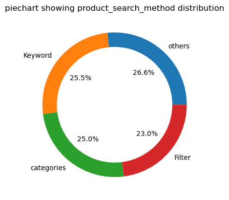

```python
plt.pie(df.product_search_method.value_counts(),labels=df.product_search_method.value_counts().index,autopct='%0.1f%%',wedgeprops=dict(width=0.2))
plt.title('piechart showing product_search_method distribution');
```

```python
df[['cart_abandonment_factors']].value_counts()
```

```
cart_abandonment_factors
Found a better price elsewhere                155
others                                        139
High shipping costs                           136
Changed my mind or no longer need the item    123
Name: count, dtype: int64
```

[figure not shown]

```python
plt.pie(df[['cart_abandonment_factors']].value_counts(),labels=df[['cart_abandonment_factors']].value_counts().index,autopct='%0.1f%%',wedgeprops=dict(width=0.2))
plt.title('piechart showing product_search_method distribution');
```

**'found a better price elsewhere' is the most comman factor for cart abandonment**

## Calculate mean and median satisfaction, recommendation helpfulness, and rating accuracy.

```python
df.shopping_satisfaction
```

```
0      3
2      3
5      4
7      2
8      2
      ..
794    1
795    2
797    4
798    3
799    2
Name: shopping_satisfaction, Length: 553, dtype: int64
```

```python
df.shopping_satisfaction.describe()
```

```
count    553.000000
mean       2.934901
std        1.401123
min        1.000000
25%        2.000000
50%        3.000000
75%        4.000000
max        5.000000
Name: shopping_satisfaction, dtype: float64
```

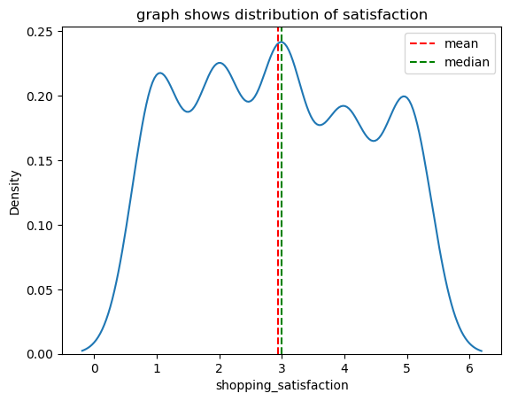

```python
sns.kdeplot(data=df,x='shopping_satisfaction')
plt.axvline(x=df['shopping_satisfaction'].mean(),color='red',ls='--',label='mean')
plt.axvline(x=df['shopping_satisfaction'].median(),color='green',ls='--',label='median')
plt.legend()
plt.title('graph shows distribution of satisfaction');
```

### recommendation_helpfulness

```python
df.recommendation_helpfulness
```

```
0            Yes
2      Sometimes
5      Sometimes
7      Sometimes
8      Sometimes
         ...
794    Sometimes
795    Sometimes
797          Yes
798    Sometimes
799    Sometimes
Name: recommendation_helpfulness, Length: 553, dtype: object
```

```python
df.recommendation_helpfulness.value_counts()
```

```
recommendation_helpfulness
No           207
Yes          181
Sometimes    165
Name: count, dtype: int64
```

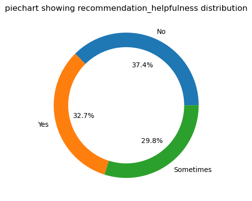

```python
plt.pie(df.recommendation_helpfulness.value_counts(),labels=df.recommendation_helpfulness.value_counts().index,autopct='%0.1f%%',wedgeprops=dict(width=0.2))
plt.title('piechart showing recommendation_helpfulness distribution');
```

**NO is the most frequent answer for recommendation_helpfulness**

```python
df.rating_accuracy
```

```
0      3
2      3
5      4
7      5
8      1
      ..
794    4
795    4
797    2
798    4
799    3
Name: rating_accuracy, Length: 553, dtype: int64
```

```python
df.rating_accuracy.describe()
```

```
count    553.000000
mean       2.962025
std        1.433428
min        1.000000
25%        2.000000
50%        3.000000
75%        4.000000
max        5.000000
Name: rating_accuracy, dtype: float64
```

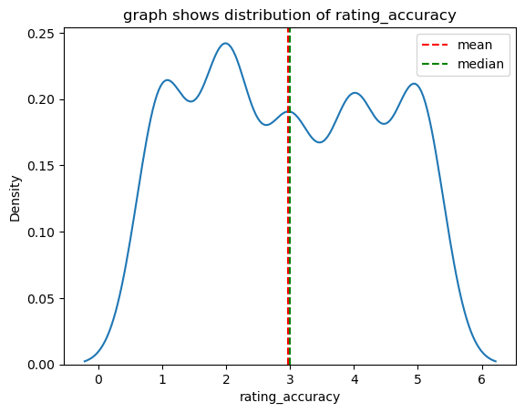

```python
sns.kdeplot(data=df,x='rating_accuracy')
plt.axvline(x=df['rating_accuracy'].mean(),color='red',ls='--',label='mean')
plt.axvline(x=df['rating_accuracy'].median(),color='green',ls='--',label='median')
plt.legend()
plt.title('graph shows distribution of rating_accuracy');
```

# Task 3: Customer Segmentation and Profiling

## Segment customers based on purchase frequency and shopping satisfaction levels.

```python
df.purchase_frequency
```

```
0      3
2      4
5      4
7      3
8      1
      ..
794    4
795    0
797    4
798    4
799    4
Name: purchase_frequency, Length: 553, dtype: object
```

**['Less than once a month','Once a month','Few times a month','Once a week', 'Multiple times a week'] as 0,1,2,3,4**

```python
 df.purchase_frequency.unique()
```

```
array(['3', '4', '1', '0', '2'], dtype=object)
```

```python
# customers with purchase_frequency less than once in a month
Less_than_once_a_month=df[df['purchase_frequency']=='0']
Less_than_once_a_month
```

|  | age | gender | purchase_frequency | purchase_categories | browsing_frequency | product_search_method | search_result_exploration | customer_reviews_importance | add_to_cart_browsing | cart_completion_frequency | ... | personalized_recommendation_frequency | recommendation_helpfulness | rating_accuracy | shopping_satisfaction | service_appreciation | improvement_areas | transaction | date | time | am_pm |
| --- | --- | --- | --- | --- | --- | --- | --- | --- | --- | --- | --- | --- | --- | --- | --- | --- | --- | --- | --- | --- | --- |
| 10 | 28 | 0 | 0 | Beauty and Personal Care;Clothing and Fashion;... | 3 | Keyword | First page | 5 | Yes | Often | ... | 5 | Sometimes | 4 | 4 | Customer service | Customer service responsiveness | 797322 | 2023-06-07 | 22:10:58 | PM |
| 18 | 51 | 2 | 0 | Groceries and Gourmet Food;Beauty and Personal... | 0 | Keyword | First page | 5 | Yes | Rarely | ... | 1 | Sometimes | 3 | 3 | Quick delivery | I don't have any problem with Amazon | 119213 | 2023-06-09 | 14:51:07 | PM |
| 20 | 28 | 3 | 0 | Groceries and Gourmet Food;Beauty and Personal... | 0 | categories | First page | 3 | Yes | Rarely | ... | 1 | No | 2 | 4 | All the above | Customer service responsiveness | 133335 | 2023-06-08 | 03:23:58 | AM |
| 21 | 10 | 2 | 0 | Groceries and Gourmet Food;Beauty and Personal... | 2 | others | Multiple pages | 5 | No | Sometimes | ... | 2 | Sometimes | 5 | 2 | Customer service | Shipping speed and reliability | 886529 | 2023-06-06 | 20:56:17 | PM |
| 25 | 40 | 0 | 0 | Beauty and Personal Care;Clothing and Fashion | 0 | Filter | Multiple pages | 4 | Yes | Always | ... | 4 | Yes | 3 | 2 | Quick delivery | Shipping speed and reliability | 608249 | 2023-06-11 | 23:20:18 | PM |
| ... | ... | ... | ... | ... | ... | ... | ... | ... | ... | ... | ... | ... | ... | ... | ... | ... | ... | ... | ... | ... | ... |
| 756 | 10 | 0 | 0 | Beauty and Personal Care;Clothing and Fashion;... | 3 | others | Multiple pages | 3 | Maybe | Often | ... | 3 | Sometimes | 1 | 4 | Wide product selection | Customer service responsiveness | 507435 | 2023-06-04 | 23:27:53 | PM |
| 761 | 39 | 1 | 0 | Beauty and Personal Care;Clothing and Fashion;... | 3 | Keyword | Multiple pages | 2 | No | Sometimes | ... | 1 | Yes | 2 | 3 | Quick delivery | Nil | 540446 | 2023-06-05 | 09:20:17 | AM |
| 782 | 51 | 2 | 0 | Groceries and Gourmet Food;Beauty and Personal... | 2 | Keyword | Multiple pages | 4 | Yes | Sometimes | ... | 3 | Sometimes | 3 | 3 | Customer service | User interface of app | 751973 | 2023-06-08 | 21:40:24 | PM |
| 793 | 4 | 3 | 0 | Clothing and Fashion;Home and Kitchen;others | 2 | others | Multiple pages | 2 | Maybe | Always | ... | 5 | Yes | 1 | 3 | User-friendly website/app interface | Reducing packaging waste | 537502 | 2023-06-09 | 09:37:44 | AM |
| 795 | 60 | 3 | 0 | Groceries and Gourmet Food;Beauty and Personal... | 3 | others | First page | 5 | Yes | Sometimes | ... | 3 | Sometimes | 4 | 2 | Customer service | Nothing | 526649 | 2023-06-11 | 14:07:39 | PM |

119 rows × 25 columns

**there are 119 customers with purchase_frequency less than once in a month**

```python
# customers with purchase_frequency Once a month
df[df['purchase_frequency']=='1']
```

|  | age | gender | purchase_frequency | purchase_categories | browsing_frequency | product_search_method | search_result_exploration | customer_reviews_importance | add_to_cart_browsing | cart_completion_frequency | ... | personalized_recommendation_frequency | recommendation_helpfulness | rating_accuracy | shopping_satisfaction | service_appreciation | improvement_areas | transaction | date | time | am_pm |
| --- | --- | --- | --- | --- | --- | --- | --- | --- | --- | --- | --- | --- | --- | --- | --- | --- | --- | --- | --- | --- | --- |
| 8 | 8 | 1 | 1 | Clothing and Fashion | 2 | Filter | First page | 3 | Yes | Rarely | ... | 5 | Sometimes | 1 | 2 | All the above | No problems with Amazon | 571022 | 2023-06-08 | 21:39:55 | PM |
| 29 | 15 | 0 | 1 | Groceries and Gourmet Food;Beauty and Personal... | 2 | others | Multiple pages | 3 | Yes | Never | ... | 2 | Sometimes | 1 | 5 | Quick delivery | No problems with Amazon | 263120 | 2023-06-07 | 22:10:26 | PM |
| 36 | 54 | 2 | 1 | Beauty and Personal Care;Clothing and Fashion;... | 1 | others | Multiple pages | 4 | Maybe | Often | ... | 5 | Yes | 4 | 5 | User-friendly website/app interface | Nil | 724960 | 2023-06-08 | 03:28:23 | AM |
| 40 | 16 | 3 | 1 | Clothing and Fashion;others | 2 | others | First page | 3 | No | Always | ... | 3 | No | 4 | 3 | Product recommendations | better app interface and lower shipping charges | 659706 | 2023-06-12 | 14:41:06 | PM |
| 44 | 9 | 0 | 1 | Clothing and Fashion;Home and Kitchen | 1 | Keyword | First page | 2 | Yes | Never | ... | 2 | No | 1 | 1 | All the above | Quality of product is very poor according to t... | 588218 | 2023-06-04 | 22:13:28 | PM |
| ... | ... | ... | ... | ... | ... | ... | ... | ... | ... | ... | ... | ... | ... | ... | ... | ... | ... | ... | ... | ... | ... |
| 769 | 67 | 0 | 1 | Home and Kitchen;others | 2 | Filter | First page | 4 | Yes | Never | ... | 2 | Sometimes | 5 | 2 | Customer service | Product quality and accuracy | 771708 | 2023-06-08 | 17:06:30 | PM |
| 784 | 29 | 3 | 1 | Clothing and Fashion;Home and Kitchen | 1 | Filter | First page | 1 | Maybe | Sometimes | ... | 5 | No | 5 | 2 | User-friendly website/app interface | Add more familiar brands to the list | 299929 | 2023-06-04 | 18:31:41 | PM |
| 787 | 43 | 0 | 1 | Beauty and Personal Care;Clothing and Fashion;... | 2 | Filter | Multiple pages | 1 | Yes | Often | ... | 2 | No | 4 | 2 | Customer service | User interface | 668260 | 2023-06-07 | 09:32:38 | AM |
| 790 | 46 | 0 | 1 | Groceries and Gourmet Food;Home and Kitchen;ot... | 3 | Keyword | First page | 5 | No | Rarely | ... | 3 | No | 4 | 1 | All the above | Irrelevant product suggestions | 720260 | 2023-06-06 | 19:10:14 | PM |
| 792 | 64 | 3 | 1 | Groceries and Gourmet Food;Home and Kitchen | 3 | Filter | First page | 4 | No | Always | ... | 4 | No | 2 | 4 | Quick delivery | better app interface and lower shipping charges | 545801 | 2023-06-09 | 19:24:06 | PM |

96 rows × 25 columns

**there are 96 customers with purchase_frequency once in a month**

```python
# customers with purchase_frequency Few times a month
df[df['purchase_frequency']=='2']
```

|  | age | gender | purchase_frequency | purchase_categories | browsing_frequency | product_search_method | search_result_exploration | customer_reviews_importance | add_to_cart_browsing | cart_completion_frequency | ... | personalized_recommendation_frequency | recommendation_helpfulness | rating_accuracy | shopping_satisfaction | service_appreciation | improvement_areas | transaction | date | time | am_pm |
| --- | --- | --- | --- | --- | --- | --- | --- | --- | --- | --- | --- | --- | --- | --- | --- | --- | --- | --- | --- | --- | --- |
| 14 | 15 | 1 | 2 | Beauty and Personal Care;Clothing and Fashion | 2 | categories | First page | 4 | Yes | Often | ... | 3 | No | 4 | 5 | Customer service | I have no problem with Amazon yet. But others ... | 397056 | 2023-06-09 | 08:10:05 | AM |
| 42 | 48 | 3 | 2 | Beauty and Personal Care;others | 1 | Keyword | Multiple pages | 1 | No | Always | ... | 4 | Sometimes | 2 | 1 | Wide product selection | No problems with Amazon | 922302 | 2023-06-08 | 22:24:19 | PM |
| 51 | 8 | 1 | 2 | Groceries and Gourmet Food;Home and Kitchen;ot... | 0 | categories | Multiple pages | 5 | Maybe | Always | ... | 2 | Yes | 2 | 4 | Wide product selection | Product quality and accuracy | 106395 | 2023-06-07 | 22:42:24 | PM |
| 57 | 58 | 0 | 2 | Beauty and Personal Care;Clothing and Fashion;... | 0 | Filter | First page | 5 | No | Sometimes | ... | 3 | No | 2 | 2 | User-friendly website/app interface | No problems with Amazon | 453417 | 2023-06-04 | 19:13:12 | PM |
| 60 | 59 | 1 | 2 | Groceries and Gourmet Food;Beauty and Personal... | 1 | Keyword | First page | 2 | Maybe | Often | ... | 4 | No | 5 | 1 | Customer service | I have no problem with Amazon yet. But others ... | 293476 | 2023-06-11 | 22:44:01 | PM |
| ... | ... | ... | ... | ... | ... | ... | ... | ... | ... | ... | ... | ... | ... | ... | ... | ... | ... | ... | ... | ... | ... |
| 772 | 55 | 2 | 2 | Beauty and Personal Care;Clothing and Fashion | 0 | Keyword | First page | 1 | No | Sometimes | ... | 4 | No | 5 | 1 | Competitive prices | Quality of product is very poor according to t... | 850593 | 2023-06-08 | 17:07:35 | PM |
| 777 | 40 | 0 | 2 | Clothing and Fashion;Home and Kitchen | 1 | others | First page | 2 | Maybe | Sometimes | ... | 5 | Yes | 5 | 2 | Competitive prices | Reducing packaging waste | 880702 | 2023-06-08 | 17:43:45 | PM |
| 781 | 8 | 0 | 2 | Beauty and Personal Care;Clothing and Fashion;... | 0 | Keyword | First page | 3 | No | Sometimes | ... | 3 | No | 5 | 1 | Customer service | I don't have any problem with Amazon | 708679 | 2023-06-09 | 10:28:57 | AM |
| 785 | 60 | 1 | 2 | Groceries and Gourmet Food;Beauty and Personal... | 3 | others | Multiple pages | 5 | Maybe | Rarely | ... | 1 | No | 2 | 3 | Competitive prices | Nil | 190661 | 2023-06-05 | 00:05:20 | AM |
| 788 | 47 | 0 | 2 | Beauty and Personal Care;Clothing and Fashion | 2 | Keyword | Multiple pages | 4 | No | Often | ... | 3 | Yes | 3 | 3 | Product recommendations | Product quality and accuracy | 102172 | 2023-06-11 | 22:43:19 | PM |

108 rows × 25 columns

**there are 108 customers with purchase_frequency Few times a month**

```python
# customers with purchase_frequency Once a week
df[df['purchase_frequency']=='3']
```

|  | age | gender | purchase_frequency | purchase_categories | browsing_frequency | product_search_method | search_result_exploration | customer_reviews_importance | add_to_cart_browsing | cart_completion_frequency | ... | personalized_recommendation_frequency | recommendation_helpfulness | rating_accuracy | shopping_satisfaction | service_appreciation | improvement_areas | transaction | date | time | am_pm |
| --- | --- | --- | --- | --- | --- | --- | --- | --- | --- | --- | --- | --- | --- | --- | --- | --- | --- | --- | --- | --- | --- |
| 0 | 59 | 0 | 3 | Beauty and Personal Care | 0 | others | Multiple pages | 4 | Yes | Rarely | ... | 1 | Yes | 3 | 3 | Customer service | User interface of app | 433348 | 2023-06-07 | 23:06:40 | PM |
| 7 | 30 | 3 | 3 | Groceries and Gourmet Food;Beauty and Personal... | 0 | categories | First page | 2 | Yes | Always | ... | 1 | Sometimes | 5 | 2 | Wide product selection | No problems with Amazon | 372797 | 2023-06-06 | 17:16:58 | PM |
| 9 | 11 | 1 | 3 | Clothing and Fashion | 0 | categories | Multiple pages | 3 | Yes | Sometimes | ... | 3 | No | 2 | 3 | Customer service | Irrelevant product suggestions | 952835 | 2023-06-11 | 23:10:14 | PM |
| 15 | 58 | 3 | 3 | Groceries and Gourmet Food;Clothing and Fashio... | 1 | categories | Multiple pages | 4 | Yes | Always | ... | 3 | No | 4 | 2 | Product recommendations | Shipping speed and reliability | 757928 | 2023-06-07 | 11:41:56 | AM |
| 17 | 60 | 0 | 3 | Clothing and Fashion;Home and Kitchen;others | 2 | others | First page | 4 | Yes | Sometimes | ... | 4 | Sometimes | 3 | 4 | Customer service | I have no problem with Amazon yet. But others ... | 701440 | 2023-06-04 | 20:00:11 | PM |
| ... | ... | ... | ... | ... | ... | ... | ... | ... | ... | ... | ... | ... | ... | ... | ... | ... | ... | ... | ... | ... | ... |
| 710 | 58 | 2 | 3 | Groceries and Gourmet Food;Home and Kitchen;ot... | 0 | Keyword | First page | 1 | Yes | Always | ... | 2 | No | 1 | 2 | Quick delivery | better app interface and lower shipping charges | 823667 | 2023-06-08 | 17:42:23 | PM |
| 728 | 28 | 2 | 3 | Beauty and Personal Care;Clothing and Fashion;... | 1 | categories | First page | 3 | Maybe | Sometimes | ... | 5 | No | 5 | 2 | Product recommendations | Shipping speed and reliability | 745511 | 2023-06-08 | 03:24:37 | AM |
| 759 | 63 | 2 | 3 | Groceries and Gourmet Food;Beauty and Personal... | 2 | Filter | First page | 5 | Yes | Never | ... | 2 | No | 2 | 5 | Competitive prices | Reducing packaging waste | 565915 | 2023-06-07 | 21:18:55 | PM |
| 767 | 51 | 1 | 3 | Beauty and Personal Care;Clothing and Fashion;... | 1 | categories | Multiple pages | 5 | Maybe | Never | ... | 1 | Yes | 3 | 1 | Customer service | No problems with Amazon | 818624 | 2023-06-07 | 11:41:56 | AM |
| 786 | 22 | 0 | 3 | Home and Kitchen | 0 | others | Multiple pages | 2 | No | Never | ... | 3 | No | 2 | 4 | Competitive prices | Irrelevant product suggestions | 556093 | 2023-06-09 | 15:24:36 | PM |

110 rows × 25 columns

**there are 110 customers with purchase_frequency Once a week**

```python
# customers with purchase_frequency Multiple times a week
df[df['purchase_frequency']=='4']
```

|  | age | gender | purchase_frequency | purchase_categories | browsing_frequency | product_search_method | search_result_exploration | customer_reviews_importance | add_to_cart_browsing | cart_completion_frequency | ... | personalized_recommendation_frequency | recommendation_helpfulness | rating_accuracy | shopping_satisfaction | service_appreciation | improvement_areas | transaction | date | time | am_pm |
| --- | --- | --- | --- | --- | --- | --- | --- | --- | --- | --- | --- | --- | --- | --- | --- | --- | --- | --- | --- | --- | --- |
| 2 | 57 | 2 | 4 | Groceries and Gourmet Food | 1 | Keyword | First page | 2 | Yes | Never | ... | 5 | Sometimes | 3 | 3 | Customer service | Product quality and accuracy | 119350 | 2023-06-08 | 21:39:30 | PM |
| 5 | 33 | 1 | 4 | Groceries and Gourmet Food;Beauty and Personal... | 0 | categories | Multiple pages | 3 | No | Often | ... | 5 | Sometimes | 4 | 4 | Customer service | Customer service responsiveness | 116480 | 2023-06-04 | 23:27:53 | PM |
| 13 | 48 | 3 | 4 | Groceries and Gourmet Food;Beauty and Personal... | 2 | others | First page | 5 | Maybe | Often | ... | 3 | Sometimes | 5 | 5 | Competitive prices | Nothing | 769031 | 2023-06-08 | 17:15:27 | PM |
| 26 | 52 | 2 | 4 | Groceries and Gourmet Food;Beauty and Personal... | 2 | others | First page | 2 | No | Always | ... | 5 | Sometimes | 2 | 5 | Wide product selection | better app interface and lower shipping charges | 749594 | 2023-06-10 | 14:41:51 | PM |
| 33 | 57 | 2 | 4 | Groceries and Gourmet Food;Beauty and Personal... | 3 | categories | Multiple pages | 5 | Yes | Never | ... | 4 | Sometimes | 4 | 3 | Wide product selection | Quality of product is very poor according to t... | 703143 | 2023-06-08 | 22:40:33 | PM |
| ... | ... | ... | ... | ... | ... | ... | ... | ... | ... | ... | ... | ... | ... | ... | ... | ... | ... | ... | ... | ... | ... |
| 791 | 43 | 3 | 4 | Beauty and Personal Care;Home and Kitchen;others | 1 | others | First page | 1 | Maybe | Often | ... | 4 | No | 3 | 3 | Wide product selection | Scrolling option would be much better than goi... | 777634 | 2023-06-05 | 00:05:20 | AM |
| 794 | 19 | 3 | 4 | Groceries and Gourmet Food;Clothing and Fashio... | 0 | Keyword | Multiple pages | 3 | Yes | Rarely | ... | 4 | Sometimes | 4 | 1 | Competitive prices | Add more familiar brands to the list | 312813 | 2023-06-07 | 12:13:39 | PM |
| 797 | 48 | 1 | 4 | Groceries and Gourmet Food | 3 | others | Multiple pages | 5 | Yes | Often | ... | 5 | Yes | 2 | 4 | Wide product selection | Product quality and accuracy | 637762 | 2023-06-12 | 15:47:01 | PM |
| 798 | 40 | 3 | 4 | Groceries and Gourmet Food;Beauty and Personal... | 0 | Keyword | Multiple pages | 2 | No | Always | ... | 4 | Sometimes | 4 | 3 | Quick delivery | Nil | 290410 | 2023-06-06 | 18:51:13 | PM |
| 799 | 67 | 0 | 4 | Clothing and Fashion;Home and Kitchen | 3 | Keyword | First page | 2 | Yes | Sometimes | ... | 1 | Sometimes | 3 | 2 | All the above | Irrelevant product suggestions | 867703 | 2023-06-09 | 10:26:51 | AM |

120 rows × 25 columns

**there are 120 customers with purchase_frequency Multiple times a week**

```python
df.purchase_frequency.value_counts()
```

```
purchase_frequency
4    120
0    119
3    110
2    108
1     96
Name: count, dtype: int64
```

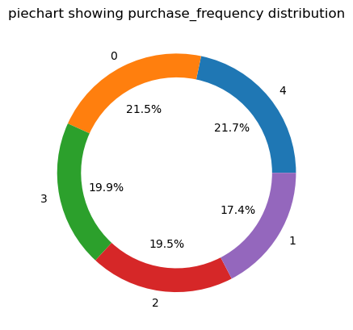

```python
plt.pie(df.purchase_frequency.value_counts(),labels=df.purchase_frequency.value_counts().index,autopct='%0.1f%%',wedgeprops=dict(width=0.2))
plt.title('piechart showing purchase_frequency distribution');
```

### shopping_satisfaction

```python
df.shopping_satisfaction.describe()
```

```
count    553.000000
mean       2.934901
std        1.401123
min        1.000000
25%        2.000000
50%        3.000000
75%        4.000000
max        5.000000
Name: shopping_satisfaction, dtype: float64
```

**as we can see mean of satisfaction level is 2.9 and 75 percintile is 4, so taking threshold as 4 segementing the custoers as high and below 3 as low and between 3 and 4 as mid**

```python
df[df['shopping_satisfaction']>=4]
```

|  | age | gender | purchase_frequency | purchase_categories | browsing_frequency | product_search_method | search_result_exploration | customer_reviews_importance | add_to_cart_browsing | cart_completion_frequency | ... | personalized_recommendation_frequency | recommendation_helpfulness | rating_accuracy | shopping_satisfaction | service_appreciation | improvement_areas | transaction | date | time | am_pm |
| --- | --- | --- | --- | --- | --- | --- | --- | --- | --- | --- | --- | --- | --- | --- | --- | --- | --- | --- | --- | --- | --- |
| 5 | 33 | 1 | 4 | Groceries and Gourmet Food;Beauty and Personal... | 0 | categories | Multiple pages | 3 | No | Often | ... | 5 | Sometimes | 4 | 4 | Customer service | Customer service responsiveness | 116480 | 2023-06-04 | 23:27:53 | PM |
| 10 | 28 | 0 | 0 | Beauty and Personal Care;Clothing and Fashion;... | 3 | Keyword | First page | 5 | Yes | Often | ... | 5 | Sometimes | 4 | 4 | Customer service | Customer service responsiveness | 797322 | 2023-06-07 | 22:10:58 | PM |
| 13 | 48 | 3 | 4 | Groceries and Gourmet Food;Beauty and Personal... | 2 | others | First page | 5 | Maybe | Often | ... | 3 | Sometimes | 5 | 5 | Competitive prices | Nothing | 769031 | 2023-06-08 | 17:15:27 | PM |
| 14 | 15 | 1 | 2 | Beauty and Personal Care;Clothing and Fashion | 2 | categories | First page | 4 | Yes | Often | ... | 3 | No | 4 | 5 | Customer service | I have no problem with Amazon yet. But others ... | 397056 | 2023-06-09 | 08:10:05 | AM |
| 17 | 60 | 0 | 3 | Clothing and Fashion;Home and Kitchen;others | 2 | others | First page | 4 | Yes | Sometimes | ... | 4 | Sometimes | 3 | 4 | Customer service | I have no problem with Amazon yet. But others ... | 701440 | 2023-06-04 | 20:00:11 | PM |
| ... | ... | ... | ... | ... | ... | ... | ... | ... | ... | ... | ... | ... | ... | ... | ... | ... | ... | ... | ... | ... | ... |
| 759 | 63 | 2 | 3 | Groceries and Gourmet Food;Beauty and Personal... | 2 | Filter | First page | 5 | Yes | Never | ... | 2 | No | 2 | 5 | Competitive prices | Reducing packaging waste | 565915 | 2023-06-07 | 21:18:55 | PM |
| 762 | 15 | 2 | 1 | Beauty and Personal Care;Clothing and Fashion;... | 2 | Filter | First page | 2 | Maybe | Rarely | ... | 5 | Yes | 1 | 4 | Product recommendations | I don't have any problem with Amazon | 186046 | 2023-06-12 | 16:02:02 | PM |
| 786 | 22 | 0 | 3 | Home and Kitchen | 0 | others | Multiple pages | 2 | No | Never | ... | 3 | No | 2 | 4 | Competitive prices | Irrelevant product suggestions | 556093 | 2023-06-09 | 15:24:36 | PM |
| 792 | 64 | 3 | 1 | Groceries and Gourmet Food;Home and Kitchen | 3 | Filter | First page | 4 | No | Always | ... | 4 | No | 2 | 4 | Quick delivery | better app interface and lower shipping charges | 545801 | 2023-06-09 | 19:24:06 | PM |
| 797 | 48 | 1 | 4 | Groceries and Gourmet Food | 3 | others | Multiple pages | 5 | Yes | Often | ... | 5 | Yes | 2 | 4 | Wide product selection | Product quality and accuracy | 637762 | 2023-06-12 | 15:47:01 | PM |

201 rows × 25 columns

**there are 201customers with more than 4 satisfaction level**

```python
df[df['shopping_satisfaction']<3]
```

|  | age | gender | purchase_frequency | purchase_categories | browsing_frequency | product_search_method | search_result_exploration | customer_reviews_importance | add_to_cart_browsing | cart_completion_frequency | ... | personalized_recommendation_frequency | recommendation_helpfulness | rating_accuracy | shopping_satisfaction | service_appreciation | improvement_areas | transaction | date | time | am_pm |
| --- | --- | --- | --- | --- | --- | --- | --- | --- | --- | --- | --- | --- | --- | --- | --- | --- | --- | --- | --- | --- | --- |
| 7 | 30 | 3 | 3 | Groceries and Gourmet Food;Beauty and Personal... | 0 | categories | First page | 2 | Yes | Always | ... | 1 | Sometimes | 5 | 2 | Wide product selection | No problems with Amazon | 372797 | 2023-06-06 | 17:16:58 | PM |
| 8 | 8 | 1 | 1 | Clothing and Fashion | 2 | Filter | First page | 3 | Yes | Rarely | ... | 5 | Sometimes | 1 | 2 | All the above | No problems with Amazon | 571022 | 2023-06-08 | 21:39:55 | PM |
| 15 | 58 | 3 | 3 | Groceries and Gourmet Food;Clothing and Fashio... | 1 | categories | Multiple pages | 4 | Yes | Always | ... | 3 | No | 4 | 2 | Product recommendations | Shipping speed and reliability | 757928 | 2023-06-07 | 11:41:56 | AM |
| 21 | 10 | 2 | 0 | Groceries and Gourmet Food;Beauty and Personal... | 2 | others | Multiple pages | 5 | No | Sometimes | ... | 2 | Sometimes | 5 | 2 | Customer service | Shipping speed and reliability | 886529 | 2023-06-06 | 20:56:17 | PM |
| 25 | 40 | 0 | 0 | Beauty and Personal Care;Clothing and Fashion | 0 | Filter | Multiple pages | 4 | Yes | Always | ... | 4 | Yes | 3 | 2 | Quick delivery | Shipping speed and reliability | 608249 | 2023-06-11 | 23:20:18 | PM |
| ... | ... | ... | ... | ... | ... | ... | ... | ... | ... | ... | ... | ... | ... | ... | ... | ... | ... | ... | ... | ... | ... |
| 787 | 43 | 0 | 1 | Beauty and Personal Care;Clothing and Fashion;... | 2 | Filter | Multiple pages | 1 | Yes | Often | ... | 2 | No | 4 | 2 | Customer service | User interface | 668260 | 2023-06-07 | 09:32:38 | AM |
| 790 | 46 | 0 | 1 | Groceries and Gourmet Food;Home and Kitchen;ot... | 3 | Keyword | First page | 5 | No | Rarely | ... | 3 | No | 4 | 1 | All the above | Irrelevant product suggestions | 720260 | 2023-06-06 | 19:10:14 | PM |
| 794 | 19 | 3 | 4 | Groceries and Gourmet Food;Clothing and Fashio... | 0 | Keyword | Multiple pages | 3 | Yes | Rarely | ... | 4 | Sometimes | 4 | 1 | Competitive prices | Add more familiar brands to the list | 312813 | 2023-06-07 | 12:13:39 | PM |
| 795 | 60 | 3 | 0 | Groceries and Gourmet Food;Beauty and Personal... | 3 | others | First page | 5 | Yes | Sometimes | ... | 3 | Sometimes | 4 | 2 | Customer service | Nothing | 526649 | 2023-06-11 | 14:07:39 | PM |
| 799 | 67 | 0 | 4 | Clothing and Fashion;Home and Kitchen | 3 | Keyword | First page | 2 | Yes | Sometimes | ... | 1 | Sometimes | 3 | 2 | All the above | Irrelevant product suggestions | 867703 | 2023-06-09 | 10:26:51 | AM |

228 rows × 25 columns

**there are 228 customers with less than 3 satisfaction level**

### Frequent Buyers: High purchase frequency, high satisfaction.

**['Less than once a month','Once a month','Few times a month','Once a week', 'Multiple times a week'] as 0,1,2,3,4**

```python
mask1 = df['purchase_frequency']=='4'
mask2 = df['shopping_satisfaction']>=3
frequent_buyers= df[(mask1) & (mask2)]
frequent_buyers
```

|  | age | gender | purchase_frequency | purchase_categories | browsing_frequency | product_search_method | search_result_exploration | customer_reviews_importance | add_to_cart_browsing | cart_completion_frequency | ... | personalized_recommendation_frequency | recommendation_helpfulness | rating_accuracy | shopping_satisfaction | service_appreciation | improvement_areas | transaction | date | time | am_pm |
| --- | --- | --- | --- | --- | --- | --- | --- | --- | --- | --- | --- | --- | --- | --- | --- | --- | --- | --- | --- | --- | --- |
| 2 | 57 | 2 | 4 | Groceries and Gourmet Food | 1 | Keyword | First page | 2 | Yes | Never | ... | 5 | Sometimes | 3 | 3 | Customer service | Product quality and accuracy | 119350 | 2023-06-08 | 21:39:30 | PM |
| 5 | 33 | 1 | 4 | Groceries and Gourmet Food;Beauty and Personal... | 0 | categories | Multiple pages | 3 | No | Often | ... | 5 | Sometimes | 4 | 4 | Customer service | Customer service responsiveness | 116480 | 2023-06-04 | 23:27:53 | PM |
| 13 | 48 | 3 | 4 | Groceries and Gourmet Food;Beauty and Personal... | 2 | others | First page | 5 | Maybe | Often | ... | 3 | Sometimes | 5 | 5 | Competitive prices | Nothing | 769031 | 2023-06-08 | 17:15:27 | PM |
| 26 | 52 | 2 | 4 | Groceries and Gourmet Food;Beauty and Personal... | 2 | others | First page | 2 | No | Always | ... | 5 | Sometimes | 2 | 5 | Wide product selection | better app interface and lower shipping charges | 749594 | 2023-06-10 | 14:41:51 | PM |
| 33 | 57 | 2 | 4 | Groceries and Gourmet Food;Beauty and Personal... | 3 | categories | Multiple pages | 5 | Yes | Never | ... | 4 | Sometimes | 4 | 3 | Wide product selection | Quality of product is very poor according to t... | 703143 | 2023-06-08 | 22:40:33 | PM |
| ... | ... | ... | ... | ... | ... | ... | ... | ... | ... | ... | ... | ... | ... | ... | ... | ... | ... | ... | ... | ... | ... |
| 766 | 18 | 0 | 4 | Home and Kitchen | 0 | Keyword | Multiple pages | 2 | No | Never | ... | 3 | Yes | 1 | 3 | Product recommendations | Nil | 679841 | 2023-06-06 | 18:32:00 | PM |
| 778 | 25 | 2 | 4 | Groceries and Gourmet Food;Beauty and Personal... | 1 | Keyword | First page | 2 | No | Rarely | ... | 3 | No | 2 | 3 | Product recommendations | Add more familiar brands to the list | 470712 | 2023-06-11 | 22:57:34 | PM |
| 791 | 43 | 3 | 4 | Beauty and Personal Care;Home and Kitchen;others | 1 | others | First page | 1 | Maybe | Often | ... | 4 | No | 3 | 3 | Wide product selection | Scrolling option would be much better than goi... | 777634 | 2023-06-05 | 00:05:20 | AM |
| 797 | 48 | 1 | 4 | Groceries and Gourmet Food | 3 | others | Multiple pages | 5 | Yes | Often | ... | 5 | Yes | 2 | 4 | Wide product selection | Product quality and accuracy | 637762 | 2023-06-12 | 15:47:01 | PM |
| 798 | 40 | 3 | 4 | Groceries and Gourmet Food;Beauty and Personal... | 0 | Keyword | Multiple pages | 2 | No | Always | ... | 4 | Sometimes | 4 | 3 | Quick delivery | Nil | 290410 | 2023-06-06 | 18:51:13 | PM |

72 rows × 25 columns

## Occasional Shoppers: Medium frequency, moderate satisfaction

```python
m1= df['shopping_satisfaction']>=3
m2 = df['shopping_satisfaction']<4
m3 = df['purchase_frequency']=='2'
```

```python
occasional_shoppers = df[m1 & m2 & m3]
occasional_shoppers
```

|  | age | gender | purchase_frequency | purchase_categories | browsing_frequency | product_search_method | search_result_exploration | customer_reviews_importance | add_to_cart_browsing | cart_completion_frequency | ... | personalized_recommendation_frequency | recommendation_helpfulness | rating_accuracy | shopping_satisfaction | service_appreciation | improvement_areas | transaction | date | time | am_pm |
| --- | --- | --- | --- | --- | --- | --- | --- | --- | --- | --- | --- | --- | --- | --- | --- | --- | --- | --- | --- | --- | --- |
| 70 | 60 | 3 | 2 | Groceries and Gourmet Food;Home and Kitchen;ot... | 0 | others | First page | 1 | No | Always | ... | 3 | Sometimes | 4 | 3 | Quick delivery | Quality of product is very poor according to t... | 543596 | 2023-06-12 | 16:02:53 | PM |
| 108 | 39 | 3 | 2 | Groceries and Gourmet Food;Beauty and Personal... | 1 | categories | First page | 4 | Maybe | Rarely | ... | 4 | Yes | 2 | 3 | Customer service | I have no problem with Amazon yet. But others ... | 527877 | 2023-06-11 | 23:19:12 | PM |
| 116 | 18 | 0 | 2 | Groceries and Gourmet Food;Beauty and Personal... | 0 | others | First page | 2 | Maybe | Rarely | ... | 3 | Yes | 2 | 3 | Wide product selection | Quality of product is very poor according to t... | 276316 | 2023-06-12 | 15:59:10 | PM |
| 155 | 28 | 0 | 2 | Groceries and Gourmet Food;Clothing and Fashio... | 0 | Filter | Multiple pages | 2 | Yes | Often | ... | 1 | No | 4 | 3 | Competitive prices | I have no problem with Amazon yet. But others ... | 485457 | 2023-06-07 | 11:54:03 | AM |
| 209 | 18 | 0 | 2 | Beauty and Personal Care;Home and Kitchen;others | 1 | Filter | Multiple pages | 4 | Yes | Never | ... | 3 | Yes | 4 | 3 | Competitive prices | I don't have any problem with Amazon | 747793 | 2023-06-09 | 19:24:06 | PM |
| 227 | 67 | 0 | 2 | Clothing and Fashion | 2 | categories | Multiple pages | 2 | No | Never | ... | 2 | No | 2 | 3 | Customer service | Product quality and accuracy | 773381 | 2023-06-05 | 00:39:14 | AM |
| 230 | 3 | 1 | 2 | Groceries and Gourmet Food;Beauty and Personal... | 0 | Filter | Multiple pages | 5 | Maybe | Never | ... | 1 | No | 1 | 3 | User-friendly website/app interface | Scrolling option would be much better than goi... | 635718 | 2023-06-04 | 19:23:21 | PM |
| 258 | 45 | 0 | 2 | Home and Kitchen;others | 1 | Filter | Multiple pages | 2 | No | Never | ... | 2 | Yes | 3 | 3 | Customer service | UI | 948730 | 2023-06-11 | 09:53:31 | AM |
| 272 | 22 | 1 | 2 | Groceries and Gourmet Food;Beauty and Personal... | 0 | others | First page | 1 | Maybe | Never | ... | 4 | No | 5 | 3 | Wide product selection | Scrolling option would be much better than goi... | 959487 | 2023-06-07 | 22:20:09 | PM |
| 312 | 63 | 2 | 2 | Beauty and Personal Care | 2 | categories | First page | 1 | Yes | Always | ... | 4 | Sometimes | 3 | 3 | Customer service | UI | 856230 | 2023-06-10 | 23:21:59 | PM |
| 318 | 53 | 2 | 2 | Beauty and Personal Care;Home and Kitchen;others | 0 | Filter | First page | 4 | Yes | Often | ... | 4 | Sometimes | 2 | 3 | Competitive prices | Customer service responsiveness | 803998 | 2023-06-05 | 20:46:09 | PM |
| 343 | 24 | 2 | 2 | Groceries and Gourmet Food;Clothing and Fashio... | 0 | Filter | First page | 5 | Maybe | Rarely | ... | 1 | No | 4 | 3 | Customer service | No problems with Amazon | 284705 | 2023-06-09 | 15:09:41 | PM |
| 376 | 45 | 3 | 2 | Home and Kitchen;others | 1 | categories | Multiple pages | 3 | Yes | Never | ... | 4 | No | 2 | 3 | Customer service | Nil | 833793 | 2023-06-06 | 19:17:17 | PM |
| 474 | 18 | 3 | 2 | Groceries and Gourmet Food | 3 | categories | Multiple pages | 1 | Yes | Often | ... | 1 | Yes | 1 | 3 | User-friendly website/app interface | User interface | 293123 | 2023-06-08 | 20:26:58 | PM |
| 476 | 61 | 1 | 2 | Clothing and Fashion;Home and Kitchen | 3 | Keyword | First page | 2 | Yes | Often | ... | 5 | No | 3 | 3 | Customer service | I have no problem with Amazon yet. But others ... | 902719 | 2023-06-04 | 18:31:41 | PM |
| 602 | 60 | 2 | 2 | Beauty and Personal Care;Clothing and Fashion;... | 0 | categories | First page | 5 | Yes | Often | ... | 5 | Sometimes | 5 | 3 | Customer service | I have no problem with Amazon yet. But others ... | 305896 | 2023-06-09 | 14:34:43 | PM |
| 618 | 44 | 0 | 2 | Groceries and Gourmet Food;Beauty and Personal... | 0 | categories | Multiple pages | 1 | No | Sometimes | ... | 2 | Yes | 1 | 3 | Quick delivery | I have no problem with Amazon yet. But others ... | 665380 | 2023-06-08 | 03:24:37 | AM |
| 674 | 61 | 1 | 2 | Groceries and Gourmet Food;Home and Kitchen | 0 | others | Multiple pages | 4 | Maybe | Often | ... | 1 | No | 2 | 3 | Quick delivery | User interface of app | 449446 | 2023-06-08 | 03:26:38 | AM |
| 677 | 35 | 1 | 2 | Clothing and Fashion;others | 3 | Keyword | Multiple pages | 3 | Maybe | Often | ... | 1 | Sometimes | 4 | 3 | Product recommendations | Irrelevant product suggestions | 497133 | 2023-06-09 | 14:39:16 | PM |
| 785 | 60 | 1 | 2 | Groceries and Gourmet Food;Beauty and Personal... | 3 | others | Multiple pages | 5 | Maybe | Rarely | ... | 1 | No | 2 | 3 | Competitive prices | Nil | 190661 | 2023-06-05 | 00:05:20 | AM |
| 788 | 47 | 0 | 2 | Beauty and Personal Care;Clothing and Fashion | 2 | Keyword | Multiple pages | 4 | No | Often | ... | 3 | Yes | 3 | 3 | Product recommendations | Product quality and accuracy | 102172 | 2023-06-11 | 22:43:19 | PM |

21 rows × 25 columns

**there are 21 ocassional customers**

## At-Risk Customers: Low satisfaction or frequent cart abandonment.

```python
df.columns
```

```
Index(['age', 'gender', 'purchase_frequency', 'purchase_categories',
       'browsing_frequency', 'product_search_method',
       'search_result_exploration', 'customer_reviews_importance',
       'add_to_cart_browsing', 'cart_completion_frequency',
       'cart_abandonment_factors', 'saveforlater_frequency', 'review_left',
       'review_reliability', 'review_helpfulness',
       'personalized_recommendation_frequency', 'recommendation_helpfulness',
       'rating_accuracy', 'shopping_satisfaction', 'service_appreciation',
       'improvement_areas', 'transaction', 'date', 'time', 'am_pm'],
      dtype='object')
```

```python
df.cart_completion_frequency
```

```
0         Rarely
2          Never
5          Often
7         Always
8         Rarely
         ...
794       Rarely
795    Sometimes
797        Often
798       Always
799    Sometimes
Name: cart_completion_frequency, Length: 553, dtype: object
```

```python
df.cart_completion_frequency.unique()
```

```
array(['Rarely', 'Never', 'Often', 'Always', 'Sometimes'], dtype=object)
```

```python
n1= df['shopping_satisfaction']<3
n2 = df['cart_completion_frequency'].isin(['Rarely','Never'])
```

```python
At_Risk_Customers=df[n1 & n2]
At_Risk_Customers
```

|  | age | gender | purchase_frequency | purchase_categories | browsing_frequency | product_search_method | search_result_exploration | customer_reviews_importance | add_to_cart_browsing | cart_completion_frequency | ... | personalized_recommendation_frequency | recommendation_helpfulness | rating_accuracy | shopping_satisfaction | service_appreciation | improvement_areas | transaction | date | time | am_pm |
| --- | --- | --- | --- | --- | --- | --- | --- | --- | --- | --- | --- | --- | --- | --- | --- | --- | --- | --- | --- | --- | --- |
| 8 | 8 | 1 | 1 | Clothing and Fashion | 2 | Filter | First page | 3 | Yes | Rarely | ... | 5 | Sometimes | 1 | 2 | All the above | No problems with Amazon | 571022 | 2023-06-08 | 21:39:55 | PM |
| 41 | 25 | 2 | 0 | Groceries and Gourmet Food;Beauty and Personal... | 2 | Filter | Multiple pages | 1 | Maybe | Never | ... | 4 | Yes | 1 | 2 | Wide product selection | I don't have any problem with Amazon | 979289 | 2023-06-09 | 14:36:46 | PM |
| 44 | 9 | 0 | 1 | Clothing and Fashion;Home and Kitchen | 1 | Keyword | First page | 2 | Yes | Never | ... | 2 | No | 1 | 1 | All the above | Quality of product is very poor according to t... | 588218 | 2023-06-04 | 22:13:28 | PM |
| 49 | 34 | 0 | 3 | others | 2 | Filter | First page | 2 | No | Rarely | ... | 4 | Yes | 3 | 2 | Customer service | No problems with Amazon | 583356 | 2023-06-08 | 09:54:40 | AM |
| 50 | 37 | 1 | 4 | Groceries and Gourmet Food;Beauty and Personal... | 0 | Keyword | First page | 5 | Maybe | Never | ... | 5 | Sometimes | 1 | 1 | Customer service | Irrelevant product suggestions | 902965 | 2023-06-09 | 14:44:09 | PM |
| ... | ... | ... | ... | ... | ... | ... | ... | ... | ... | ... | ... | ... | ... | ... | ... | ... | ... | ... | ... | ... | ... |
| 768 | 53 | 1 | 2 | Clothing and Fashion;Home and Kitchen | 3 | others | First page | 3 | Yes | Rarely | ... | 2 | No | 3 | 1 | User-friendly website/app interface | Quality of product is very poor according to t... | 660877 | 2023-06-08 | 03:23:58 | AM |
| 769 | 67 | 0 | 1 | Home and Kitchen;others | 2 | Filter | First page | 4 | Yes | Never | ... | 2 | Sometimes | 5 | 2 | Customer service | Product quality and accuracy | 771708 | 2023-06-08 | 17:06:30 | PM |
| 783 | 67 | 0 | 4 | Beauty and Personal Care;Clothing and Fashion | 1 | categories | Multiple pages | 2 | No | Never | ... | 5 | Sometimes | 1 | 1 | Quick delivery | User interface | 342559 | 2023-06-09 | 14:51:07 | PM |
| 790 | 46 | 0 | 1 | Groceries and Gourmet Food;Home and Kitchen;ot... | 3 | Keyword | First page | 5 | No | Rarely | ... | 3 | No | 4 | 1 | All the above | Irrelevant product suggestions | 720260 | 2023-06-06 | 19:10:14 | PM |
| 794 | 19 | 3 | 4 | Groceries and Gourmet Food;Clothing and Fashio... | 0 | Keyword | Multiple pages | 3 | Yes | Rarely | ... | 4 | Sometimes | 4 | 1 | Competitive prices | Add more familiar brands to the list | 312813 | 2023-06-07 | 12:13:39 | PM |

82 rows × 25 columns

**there are 82 at risk customers**

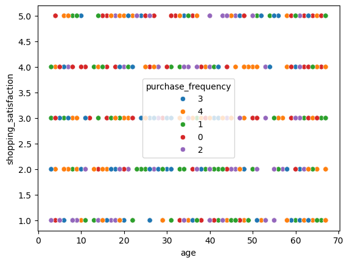

```python
sns.scatterplot(data=df, x='age', y='shopping_satisfaction',hue='purchase_frequency')
```

## Analyze demographic or behavioral differences across these segments

### purchase_categories

```python
# frequent_buyers
product_count_frequent_buyers = frequent_buyers['purchase_categories'].str.split(';').explode().value_counts().reset_index()
product_count_frequent_buyers
```

|  | purchase_categories | count |
| --- | --- | --- |
| 0 | Clothing and Fashion | 44 |
| 1 | Beauty and Personal Care | 40 |
| 2 | others | 37 |
| 3 | Home and Kitchen | 36 |
| 4 | Groceries and Gourmet Food | 33 |

```python
# occasional_shoppers
product_count_occasional_shoppers = occasional_shoppers['purchase_categories'].str.split(';').explode().value_counts().reset_index()
product_count_occasional_shoppers
```

|  | purchase_categories | count |
| --- | --- | --- |
| 0 | Home and Kitchen | 12 |
| 1 | Groceries and Gourmet Food | 11 |
| 2 | Beauty and Personal Care | 11 |
| 3 | others | 10 |
| 4 | Clothing and Fashion | 10 |

```python
# At_Risk_Customers
product_count_At_Risk_Customers = At_Risk_Customers['purchase_categories'].str.split(';').explode().value_counts().reset_index()
product_count_At_Risk_Customers
```

|  | purchase_categories | count |
| --- | --- | --- |
| 0 | Clothing and Fashion | 52 |
| 1 | Beauty and Personal Care | 46 |
| 2 | Groceries and Gourmet Food | 42 |
| 3 | Home and Kitchen | 40 |
| 4 | others | 38 |

**here we can see the change in their purchasing pattern**

### Age

```python
frequent_buyers.age.describe()
```

```
count    72.000000
mean     34.222222
std      18.958979
min       4.000000
25%      17.000000
50%      33.000000
75%      50.000000
max      67.000000
Name: age, dtype: float64
```

```python
occasional_shoppers.age.describe()
```

```
count    21.000000
mean     41.476190
std      18.906663
min       3.000000
25%      24.000000
50%      45.000000
75%      60.000000
max      67.000000
Name: age, dtype: float64
```

```python
At_Risk_Customers.age.describe()
```

```
count    82.000000
mean     33.475610
std      19.429661
min       3.000000
25%      17.250000
50%      34.500000
75%      48.750000
max      67.000000
Name: age, dtype: float64
```

```python
mean_ages = pd.DataFrame({
    'customers': ['frequent_buyers', 'occasional_shoppers', 'At_Risk_Customers'],
    'mean_age': [frequent_buyers['age'].mean(), occasional_shoppers['age'].mean(), At_Risk_Customers['age'].mean()]})
```

```python
mean_ages
```

|  | customers | mean_age |
| --- | --- | --- |
| 0 | frequent_buyers | 34.222222 |
| 1 | occasional_shoppers | 41.476190 |
| 2 | At_Risk_Customers | 33.475610 |

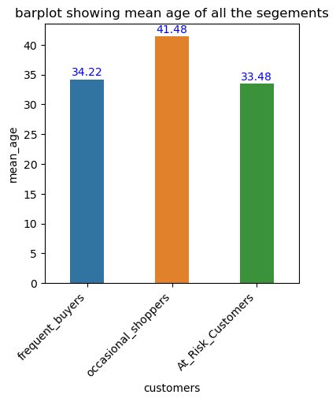

```python
plt.figure(figsize=(4,5))
ax=sns.barplot(data=mean_ages, x='customers',y='mean_age',hue='customers',width=0.4)
#ax.tick_params(axis='x', rotation=45)
plt.xticks(rotation=45,horizontalalignment='right')
for containers in ax.containers:
    ax.bar_label(containers,fmt='%.2f',padding=1,color='blue')
plt.tight_layout()
plt.title('barplot showing mean age of all the segements');
```

### Gender

```python
df.gender.unique()
```

```
array(['0', '2', '1', '3'], dtype=object)
```

**in gender ['Others', 'Female', 'Prefer not to say', 'Male']) as 0,1,2,3**

```python
frequent_buyers.gender.value_counts()
```

```
gender
2    20
1    20
3    18
0    14
Name: count, dtype: int64
```

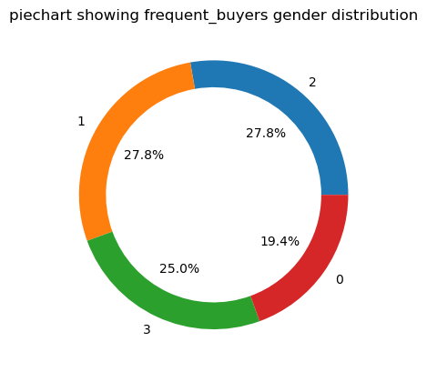

```python
plt.pie(frequent_buyers.gender.value_counts(),labels=frequent_buyers.gender.value_counts().index,autopct='%0.1f%%',wedgeprops=dict(width=0.2))
plt.title('piechart showing frequent_buyers gender distribution');
```

```python
occasional_shoppers.gender.value_counts()
```

```
gender
0    7
1    6
3    4
2    4
Name: count, dtype: int64
```

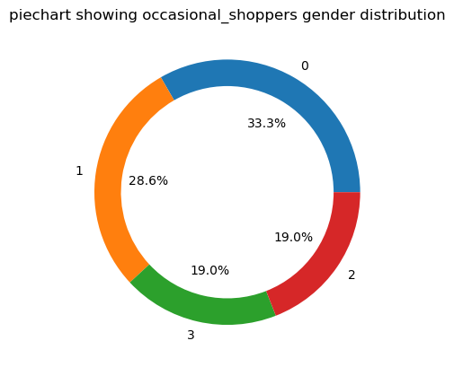

```python
plt.pie(occasional_shoppers.gender.value_counts(),labels=occasional_shoppers.gender.value_counts().index,autopct='%0.1f%%',wedgeprops=dict(width=0.2))
plt.title('piechart showing occasional_shoppers gender distribution');
```

```python
At_Risk_Customers.gender.value_counts()
```

```
gender
0    25
2    21
1    19
3    17
Name: count, dtype: int64
```

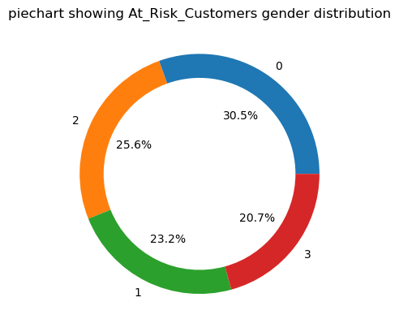

```python
plt.pie(At_Risk_Customers.gender.value_counts(),labels=At_Risk_Customers.gender.value_counts().index,autopct='%0.1f%%',wedgeprops=dict(width=0.2))
plt.title('piechart showing At_Risk_Customers gender distribution');
```

```python
df.columns
```

```
Index(['age', 'gender', 'purchase_frequency', 'purchase_categories',
       'browsing_frequency', 'product_search_method',
       'search_result_exploration', 'customer_reviews_importance',
       'add_to_cart_browsing', 'cart_completion_frequency',
       'cart_abandonment_factors', 'saveforlater_frequency', 'review_left',
       'review_reliability', 'review_helpfulness',
       'personalized_recommendation_frequency', 'recommendation_helpfulness',
       'rating_accuracy', 'shopping_satisfaction', 'service_appreciation',
       'improvement_areas', 'transaction', 'date', 'time', 'am_pm'],
      dtype='object')
```

### transaction

```python
frequent_buyers.transaction.describe()
```

```
count        72.000000
mean     545963.958333
std      256890.741055
min      101357.000000
25%      332525.000000
50%      594768.000000
75%      732859.250000
max      988894.000000
Name: transaction, dtype: float64
```

```python
occasional_shoppers.transaction.describe()
```

```
count        21.000000
mean     575410.047619
std      264968.109112
min      102172.000000
25%      305896.000000
50%      543596.000000
75%      803998.000000
max      959487.000000
Name: transaction, dtype: float64
```

```python
At_Risk_Customers.transaction.describe()
```

```
count        82.000000
mean     528514.378049
std      256666.461451
min      101141.000000
25%      306626.750000
50%      536524.500000
75%      759691.000000
max      979289.000000
Name: transaction, dtype: float64
```

```python
mean_transaction = pd.DataFrame({
    'customers': ['frequent_buyers', 'occasional_shoppers', 'At_Risk_Customers'],
    'mean_transaction': [frequent_buyers['transaction'].mean(), occasional_shoppers['transaction'].mean(), At_Risk_Customers['transaction'].mean()]})
```

```python
mean_transaction
```

|  | customers | mean_transaction |
| --- | --- | --- |
| 0 | frequent_buyers | 545963.958333 |
| 1 | occasional_shoppers | 575410.047619 |
| 2 | At_Risk_Customers | 528514.378049 |

[figure not shown]

```python
plt.figure(figsize=(4,5))
ax=sns.barplot(data=mean_transaction, x='customers',y='mean_transaction',hue='customers',width=0.4)
plt.xticks(rotation=45,horizontalalignment='right')
for containers in ax.containers:
    ax.bar_label(containers,fmt='%.2f',padding=1,color='blue')
plt.tight_layout()
plt.title('barplot showing mean age of all the segements');
```

**on average occasional_shoppers send more than others**

## Use clustering (e.g., K-Means) for behavioral grouping based on survey responses

```python
df.head()
```

|  | age | gender | purchase_frequency | purchase_categories | browsing_frequency | product_search_method | search_result_exploration | customer_reviews_importance | add_to_cart_browsing | cart_completion_frequency | ... | personalized_recommendation_frequency | recommendation_helpfulness | rating_accuracy | shopping_satisfaction | service_appreciation | improvement_areas | transaction | date | time | am_pm |
| --- | --- | --- | --- | --- | --- | --- | --- | --- | --- | --- | --- | --- | --- | --- | --- | --- | --- | --- | --- | --- | --- |
| 0 | 59 | 0 | 3 | Beauty and Personal Care | 0 | others | Multiple pages | 4 | Yes | Rarely | ... | 1 | Yes | 3 | 3 | Customer service | User interface of app | 433348 | 2023-06-07 | 23:06:40 | PM |
| 2 | 57 | 2 | 4 | Groceries and Gourmet Food | 1 | Keyword | First page | 2 | Yes | Never | ... | 5 | Sometimes | 3 | 3 | Customer service | Product quality and accuracy | 119350 | 2023-06-08 | 21:39:30 | PM |
| 5 | 33 | 1 | 4 | Groceries and Gourmet Food;Beauty and Personal... | 0 | categories | Multiple pages | 3 | No | Often | ... | 5 | Sometimes | 4 | 4 | Customer service | Customer service responsiveness | 116480 | 2023-06-04 | 23:27:53 | PM |
| 7 | 30 | 3 | 3 | Groceries and Gourmet Food;Beauty and Personal... | 0 | categories | First page | 2 | Yes | Always | ... | 1 | Sometimes | 5 | 2 | Wide product selection | No problems with Amazon | 372797 | 2023-06-06 | 17:16:58 | PM |
| 8 | 8 | 1 | 1 | Clothing and Fashion | 2 | Filter | First page | 3 | Yes | Rarely | ... | 5 | Sometimes | 1 | 2 | All the above | No problems with Amazon | 571022 | 2023-06-08 | 21:39:55 | PM |

5 rows × 25 columns

```python
#dt['gender'] = (dt['gender'].astype('category').cat.set_categories(['Others', 'Female', 'Prefer not to say', 'Male']).cat.codes.astype(str))
```

```python
df.columns
```

```
Index(['age', 'gender', 'purchase_frequency', 'purchase_categories',
       'browsing_frequency', 'product_search_method',
       'search_result_exploration', 'customer_reviews_importance',
       'add_to_cart_browsing', 'cart_completion_frequency',
       'cart_abandonment_factors', 'saveforlater_frequency', 'review_left',
       'review_reliability', 'review_helpfulness',
       'personalized_recommendation_frequency', 'recommendation_helpfulness',
       'rating_accuracy', 'shopping_satisfaction', 'service_appreciation',
       'improvement_areas', 'transaction', 'date', 'time', 'am_pm'],
      dtype='object')
```

```python
kdf = df[['age','gender','purchase_frequency','personalized_recommendation_frequency','browsing_frequency','product_search_method','search_result_exploration',
'cart_completion_frequency','recommendation_helpfulness','rating_accuracy','shopping_satisfaction','transaction']]
kdf=kdf.copy()
kdf
```

|  | age | gender | purchase_frequency | personalized_recommendation_frequency | browsing_frequency | product_search_method | search_result_exploration | cart_completion_frequency | recommendation_helpfulness | rating_accuracy | shopping_satisfaction | transaction |
| --- | --- | --- | --- | --- | --- | --- | --- | --- | --- | --- | --- | --- |
| 0 | 59 | 0 | 3 | 1 | 0 | others | Multiple pages | Rarely | Yes | 3 | 3 | 433348 |
| 2 | 57 | 2 | 4 | 5 | 1 | Keyword | First page | Never | Sometimes | 3 | 3 | 119350 |
| 5 | 33 | 1 | 4 | 5 | 0 | categories | Multiple pages | Often | Sometimes | 4 | 4 | 116480 |
| 7 | 30 | 3 | 3 | 1 | 0 | categories | First page | Always | Sometimes | 5 | 2 | 372797 |
| 8 | 8 | 1 | 1 | 5 | 2 | Filter | First page | Rarely | Sometimes | 1 | 2 | 571022 |
| ... | ... | ... | ... | ... | ... | ... | ... | ... | ... | ... | ... | ... |
| 794 | 19 | 3 | 4 | 4 | 0 | Keyword | Multiple pages | Rarely | Sometimes | 4 | 1 | 312813 |
| 795 | 60 | 3 | 0 | 3 | 3 | others | First page | Sometimes | Sometimes | 4 | 2 | 526649 |
| 797 | 48 | 1 | 4 | 5 | 3 | others | Multiple pages | Often | Yes | 2 | 4 | 637762 |
| 798 | 40 | 3 | 4 | 4 | 0 | Keyword | Multiple pages | Always | Sometimes | 4 | 3 | 290410 |
| 799 | 67 | 0 | 4 | 1 | 3 | Keyword | First page | Sometimes | Sometimes | 3 | 2 | 867703 |

553 rows × 12 columns

**insuring all of them are in numerical of categorical format**

```python
kdf.personalized_recommendation_frequency
```

```
0      1
2      5
5      5
7      1
8      5
      ..
794    4
795    3
797    5
798    4
799    1
Name: personalized_recommendation_frequency, Length: 553, dtype: int64
```

```python
kdf.product_search_method
```

```
0          others
2         Keyword
5      categories
7      categories
8          Filter
          ...
794       Keyword
795        others
797        others
798       Keyword
799       Keyword
Name: product_search_method, Length: 553, dtype: object
```

```python
kdf.product_search_method.unique()
```

```
array(['others', 'Keyword', 'categories', 'Filter'], dtype=object)
```

```python
kdf['product_search_method'] = (kdf['product_search_method'].astype('category').cat.set_categories(['others', 'Keyword', 'categories', 'Filter']).
    cat.codes.astype(str))
```

```python
kdf.search_result_exploration
```

```
0      Multiple pages
2          First page
5      Multiple pages
7          First page
8          First page
            ...
794    Multiple pages
795        First page
797    Multiple pages
798    Multiple pages
799        First page
Name: search_result_exploration, Length: 553, dtype: object
```

```python
kdf.search_result_exploration.unique()
```

```
array(['Multiple pages', 'First page'], dtype=object)
```

```python
kdf['search_result_exploration'] = (kdf['search_result_exploration'].astype('category').cat.set_categories(['Multiple pages', 'First page']).
    cat.codes.astype(str))
```

```python
kdf.cart_completion_frequency
```

```
0         Rarely
2          Never
5          Often
7         Always
8         Rarely
         ...
794       Rarely
795    Sometimes
797        Often
798       Always
799    Sometimes
Name: cart_completion_frequency, Length: 553, dtype: object
```

```python
kdf.cart_completion_frequency.unique()
```

```
array(['Rarely', 'Never', 'Often', 'Always', 'Sometimes'], dtype=object)
```

```python
kdf['cart_completion_frequency'] = (kdf['cart_completion_frequency'].astype('category').cat.set_categories(['Rarely', 'Never', 'Often', 'Always', 'Sometimes']).
    cat.codes.astype(str))
```

```python
kdf.recommendation_helpfulness
```

```
0            Yes
2      Sometimes
5      Sometimes
7      Sometimes
8      Sometimes
         ...
794    Sometimes
795    Sometimes
797          Yes
798    Sometimes
799    Sometimes
Name: recommendation_helpfulness, Length: 553, dtype: object
```

```python
kdf.recommendation_helpfulness.unique()
```

```
array(['Yes', 'Sometimes', 'No'], dtype=object)
```

```python
kdf['recommendation_helpfulness'] = (kdf['recommendation_helpfulness'].astype('category').cat.set_categories(['Yes', 'Sometimes', 'No']).
    cat.codes.astype(str))
```

```python
kdf
```

|  | age | gender | purchase_frequency | personalized_recommendation_frequency | browsing_frequency | product_search_method | search_result_exploration | cart_completion_frequency | recommendation_helpfulness | rating_accuracy | shopping_satisfaction | transaction |
| --- | --- | --- | --- | --- | --- | --- | --- | --- | --- | --- | --- | --- |
| 0 | 59 | 0 | 3 | 1 | 0 | 0 | 0 | 0 | 0 | 3 | 3 | 433348 |
| 2 | 57 | 2 | 4 | 5 | 1 | 1 | 1 | 1 | 1 | 3 | 3 | 119350 |
| 5 | 33 | 1 | 4 | 5 | 0 | 2 | 0 | 2 | 1 | 4 | 4 | 116480 |
| 7 | 30 | 3 | 3 | 1 | 0 | 2 | 1 | 3 | 1 | 5 | 2 | 372797 |
| 8 | 8 | 1 | 1 | 5 | 2 | 3 | 1 | 0 | 1 | 1 | 2 | 571022 |
| ... | ... | ... | ... | ... | ... | ... | ... | ... | ... | ... | ... | ... |
| 794 | 19 | 3 | 4 | 4 | 0 | 1 | 0 | 0 | 1 | 4 | 1 | 312813 |
| 795 | 60 | 3 | 0 | 3 | 3 | 0 | 1 | 4 | 1 | 4 | 2 | 526649 |
| 797 | 48 | 1 | 4 | 5 | 3 | 0 | 0 | 2 | 0 | 2 | 4 | 637762 |
| 798 | 40 | 3 | 4 | 4 | 0 | 1 | 0 | 3 | 1 | 4 | 3 | 290410 |
| 799 | 67 | 0 | 4 | 1 | 3 | 1 | 1 | 4 | 1 | 3 | 2 | 867703 |

553 rows × 12 columns

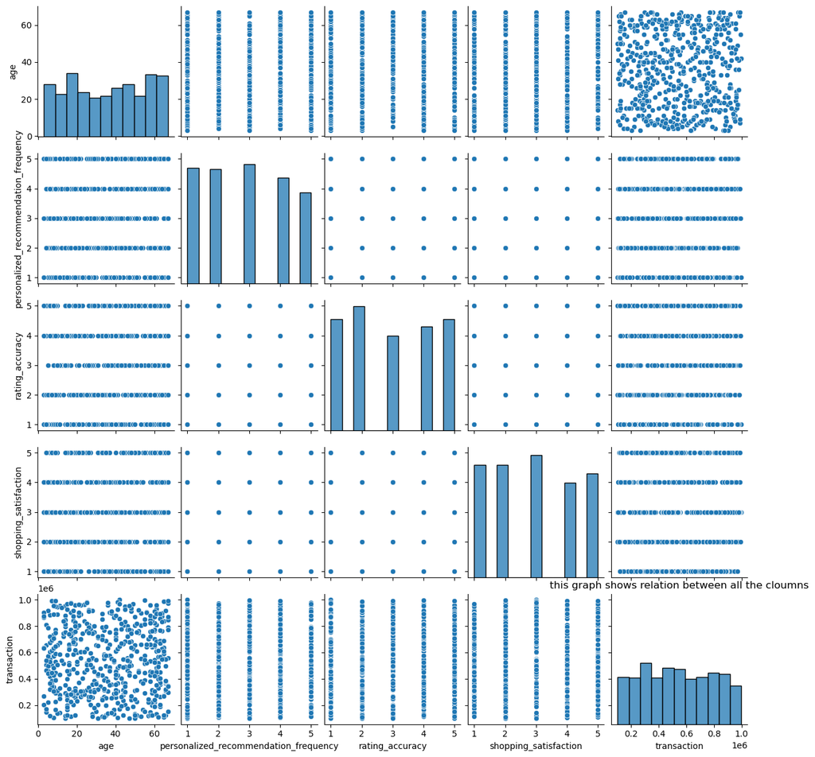

```python
sns.pairplot(kdf)
plt.title('this graph shows relation between all the cloumns');
```

```python
from sklearn.cluster import KMeans
from sklearn.metrics import silhouette_score
from sklearn.preprocessing import StandardScaler
```

```python
d=[]
for k in range(2,10):
    frog=KMeans(n_clusters=k,random_state=42)
    frog.fit_predict(kdf)
    l=frog.labels_
    s=silhouette_score(kdf,l)
    i=frog.inertia_
    print('for k =',k,' ','silhouette_score is ',s)
    print(frog.inertia_)
    d.append({'k':k,'inertia':round(i,2),'silhouette':s})
```

```
for k = 2   silhouette_score is  0.6226397296877937
9150219995954.637
for k = 3   silhouette_score is  0.5903317749561898
4056565127150.2305
for k = 4   silhouette_score is  0.5439040905992789
2534882652519.7065
for k = 5   silhouette_score is  0.5657207549709915
1477214429217.3486
for k = 6   silhouette_score is  0.5554433502899714
1044138123907.4248
for k = 7   silhouette_score is  0.5765048358396536
696547842963.4885
for k = 8   silhouette_score is  0.5622809795977861
562654861321.4653
for k = 9   silhouette_score is  0.556319530927254
443177708554.4321
```

```python
K_data = pd.DataFrame(d)
K_data['inertia'] = K_data['inertia'].astype('int64')
```

```python
K_data
```

|  | k | inertia | silhouette |
| --- | --- | --- | --- |
| 0 | 2 | 9150219995954 | 0.622640 |
| 1 | 3 | 4056565127150 | 0.590332 |
| 2 | 4 | 2534882652519 | 0.543904 |
| 3 | 5 | 1477214429217 | 0.565721 |
| 4 | 6 | 1044138123907 | 0.555443 |
| 5 | 7 | 696547842963 | 0.576505 |
| 6 | 8 | 562654861321 | 0.562281 |
| 7 | 9 | 443177708554 | 0.556320 |

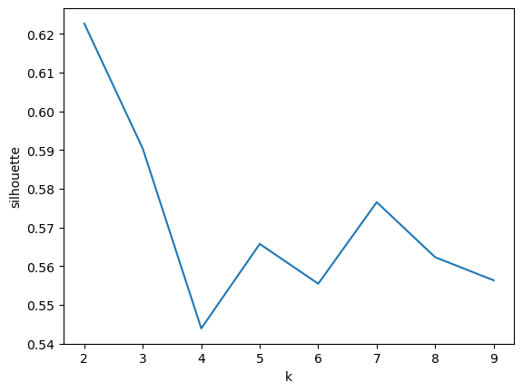

```python
sns.lineplot(data=K_data,x='k',y='silhouette')
```

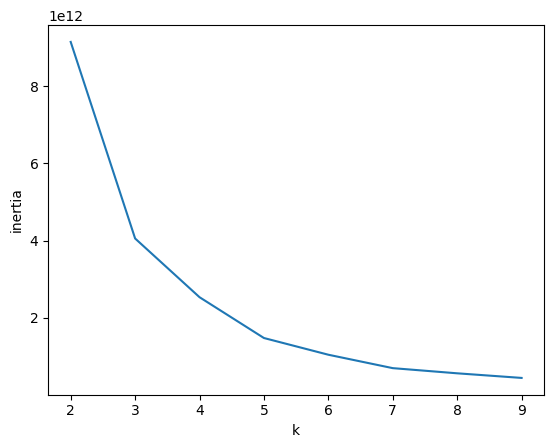

```python
sns.lineplot(data=K_data,x='k',y='inertia')
```

**looking as the inertia graph , after k at 5 inertia stops droping significantly so taking k = 5 as optimal k value**

```python
final_k = KMeans(n_clusters=5,random_state=42)
```

```python
final_k.fit_predict(kdf)
```

```
array([3, 2, 2, 0, 3, 1, 4, 4, 0, 4, 4, 2, 2, 1, 0, 3, 4, 0, 4, 4, 2, 4,
       0, 2, 4, 1, 1, 1, 3, 3, 3, 1, 2, 3, 2, 0, 3, 3, 0, 2, 3, 4, 4, 2,
       3, 0, 2, 4, 3, 3, 2, 4, 4, 0, 4, 2, 3, 0, 4, 0, 3, 0, 0, 2, 1, 1,
       2, 1, 1, 3, 2, 4, 3, 0, 4, 0, 4, 2, 0, 1, 0, 4, 4, 0, 1, 1, 0, 3,
       4, 0, 1, 2, 4, 1, 3, 0, 2, 4, 3, 3, 3, 4, 3, 2, 0, 1, 3, 4, 4, 3,
       0, 1, 4, 0, 3, 2, 3, 2, 3, 4, 2, 4, 1, 4, 0, 1, 3, 4, 2, 3, 1, 3,
       4, 3, 3, 1, 0, 4, 3, 1, 0, 4, 3, 0, 4, 0, 0, 0, 4, 4, 3, 4, 4, 3,
       3, 0, 0, 3, 3, 4, 2, 1, 3, 1, 2, 4, 1, 0, 4, 0, 1, 2, 3, 0, 0, 1,
       4, 3, 0, 2, 2, 1, 0, 2, 1, 3, 3, 0, 0, 0, 1, 4, 3, 4, 2, 3, 4, 0,
       2, 3, 3, 1, 0, 3, 2, 1, 1, 3, 2, 4, 4, 3, 0, 4, 2, 4, 1, 2, 4, 2,
       3, 0, 4, 4, 0, 0, 3, 0, 2, 4, 2, 2, 0, 2, 4, 0, 1, 0, 3, 0, 4, 4,
       4, 3, 3, 0, 0, 1, 4, 0, 1, 0, 0, 4, 1, 2, 1, 2, 2, 0, 0, 2, 0, 2,
       4, 0, 3, 1, 1, 2, 4, 1, 2, 0, 0, 0, 4, 1, 0, 4, 0, 3, 3, 0, 2, 3,
       1, 1, 2, 1, 1, 4, 1, 2, 3, 3, 1, 0, 1, 3, 1, 3, 3, 0, 0, 1, 0, 1,
       3, 3, 3, 4, 1, 3, 3, 2, 1, 4, 4, 3, 0, 0, 1, 2, 2, 4, 1, 2, 2, 4,
       3, 1, 1, 3, 3, 2, 3, 3, 4, 2, 2, 0, 4, 4, 0, 1, 4, 3, 2, 4, 3, 3,
       0, 3, 3, 3, 1, 1, 4, 0, 4, 4, 3, 4, 3, 2, 1, 0, 3, 0, 4, 4, 0, 2,
       0, 0, 3, 0, 2, 3, 0, 1, 4, 0, 2, 1, 2, 2, 3, 4, 2, 3, 4, 1, 1, 3,
       0, 0, 2, 1, 4, 0, 3, 3, 0, 1, 2, 1, 0, 4, 1, 1, 3, 4, 4, 3, 2, 0,
       0, 2, 4, 2, 4, 3, 4, 0, 4, 3, 4, 3, 4, 2, 0, 4, 1, 0, 1, 3, 0, 4,
       0, 3, 0, 1, 3, 0, 1, 0, 4, 4, 1, 3, 0, 2, 1, 1, 1, 4, 1, 1, 1, 0,
       1, 0, 3, 4, 3, 3, 0, 1, 0, 3, 3, 3, 3, 1, 3, 0, 4, 1, 4, 4, 4, 0,
       3, 4, 3, 1, 4, 0, 1, 1, 0, 0, 2, 4, 1, 3, 1, 4, 4, 2, 4, 0, 3, 1,
       4, 1, 1, 2, 1, 0, 1, 0, 4, 0, 0, 3, 0, 4, 3, 3, 3, 3, 3, 2, 0, 4,
       1, 4, 4, 1, 2, 1, 1, 3, 4, 4, 0, 0, 2, 3, 4, 2, 4, 4, 3, 3, 0, 3,
       4, 0, 1], dtype=int32)
```

```python
cluster=final_k.labels_
```

```python
cluster
```

```
array([3, 2, 2, 0, 3, 1, 4, 4, 0, 4, 4, 2, 2, 1, 0, 3, 4, 0, 4, 4, 2, 4,
       0, 2, 4, 1, 1, 1, 3, 3, 3, 1, 2, 3, 2, 0, 3, 3, 0, 2, 3, 4, 4, 2,
       3, 0, 2, 4, 3, 3, 2, 4, 4, 0, 4, 2, 3, 0, 4, 0, 3, 0, 0, 2, 1, 1,
       2, 1, 1, 3, 2, 4, 3, 0, 4, 0, 4, 2, 0, 1, 0, 4, 4, 0, 1, 1, 0, 3,
       4, 0, 1, 2, 4, 1, 3, 0, 2, 4, 3, 3, 3, 4, 3, 2, 0, 1, 3, 4, 4, 3,
       0, 1, 4, 0, 3, 2, 3, 2, 3, 4, 2, 4, 1, 4, 0, 1, 3, 4, 2, 3, 1, 3,
       4, 3, 3, 1, 0, 4, 3, 1, 0, 4, 3, 0, 4, 0, 0, 0, 4, 4, 3, 4, 4, 3,
       3, 0, 0, 3, 3, 4, 2, 1, 3, 1, 2, 4, 1, 0, 4, 0, 1, 2, 3, 0, 0, 1,
       4, 3, 0, 2, 2, 1, 0, 2, 1, 3, 3, 0, 0, 0, 1, 4, 3, 4, 2, 3, 4, 0,
       2, 3, 3, 1, 0, 3, 2, 1, 1, 3, 2, 4, 4, 3, 0, 4, 2, 4, 1, 2, 4, 2,
       3, 0, 4, 4, 0, 0, 3, 0, 2, 4, 2, 2, 0, 2, 4, 0, 1, 0, 3, 0, 4, 4,
       4, 3, 3, 0, 0, 1, 4, 0, 1, 0, 0, 4, 1, 2, 1, 2, 2, 0, 0, 2, 0, 2,
       4, 0, 3, 1, 1, 2, 4, 1, 2, 0, 0, 0, 4, 1, 0, 4, 0, 3, 3, 0, 2, 3,
       1, 1, 2, 1, 1, 4, 1, 2, 3, 3, 1, 0, 1, 3, 1, 3, 3, 0, 0, 1, 0, 1,
       3, 3, 3, 4, 1, 3, 3, 2, 1, 4, 4, 3, 0, 0, 1, 2, 2, 4, 1, 2, 2, 4,
       3, 1, 1, 3, 3, 2, 3, 3, 4, 2, 2, 0, 4, 4, 0, 1, 4, 3, 2, 4, 3, 3,
       0, 3, 3, 3, 1, 1, 4, 0, 4, 4, 3, 4, 3, 2, 1, 0, 3, 0, 4, 4, 0, 2,
       0, 0, 3, 0, 2, 3, 0, 1, 4, 0, 2, 1, 2, 2, 3, 4, 2, 3, 4, 1, 1, 3,
       0, 0, 2, 1, 4, 0, 3, 3, 0, 1, 2, 1, 0, 4, 1, 1, 3, 4, 4, 3, 2, 0,
       0, 2, 4, 2, 4, 3, 4, 0, 4, 3, 4, 3, 4, 2, 0, 4, 1, 0, 1, 3, 0, 4,
       0, 3, 0, 1, 3, 0, 1, 0, 4, 4, 1, 3, 0, 2, 1, 1, 1, 4, 1, 1, 1, 0,
       1, 0, 3, 4, 3, 3, 0, 1, 0, 3, 3, 3, 3, 1, 3, 0, 4, 1, 4, 4, 4, 0,
       3, 4, 3, 1, 4, 0, 1, 1, 0, 0, 2, 4, 1, 3, 1, 4, 4, 2, 4, 0, 3, 1,
       4, 1, 1, 2, 1, 0, 1, 0, 4, 0, 0, 3, 0, 4, 3, 3, 3, 3, 3, 2, 0, 4,
       1, 4, 4, 1, 2, 1, 1, 3, 4, 4, 0, 0, 2, 3, 4, 2, 4, 4, 3, 3, 0, 3,
       4, 0, 1], dtype=int32)
```

```python
kdf['cluster']=cluster
```

```python
kdf
```

|  | age | gender | purchase_frequency | personalized_recommendation_frequency | browsing_frequency | product_search_method | search_result_exploration | cart_completion_frequency | recommendation_helpfulness | rating_accuracy | shopping_satisfaction | transaction | cluster |
| --- | --- | --- | --- | --- | --- | --- | --- | --- | --- | --- | --- | --- | --- |
| 0 | 59 | 0 | 3 | 1 | 0 | 0 | 0 | 0 | 0 | 3 | 3 | 433348 | 3 |
| 2 | 57 | 2 | 4 | 5 | 1 | 1 | 1 | 1 | 1 | 3 | 3 | 119350 | 2 |
| 5 | 33 | 1 | 4 | 5 | 0 | 2 | 0 | 2 | 1 | 4 | 4 | 116480 | 2 |
| 7 | 30 | 3 | 3 | 1 | 0 | 2 | 1 | 3 | 1 | 5 | 2 | 372797 | 0 |
| 8 | 8 | 1 | 1 | 5 | 2 | 3 | 1 | 0 | 1 | 1 | 2 | 571022 | 3 |
| ... | ... | ... | ... | ... | ... | ... | ... | ... | ... | ... | ... | ... | ... |
| 794 | 19 | 3 | 4 | 4 | 0 | 1 | 0 | 0 | 1 | 4 | 1 | 312813 | 0 |
| 795 | 60 | 3 | 0 | 3 | 3 | 0 | 1 | 4 | 1 | 4 | 2 | 526649 | 3 |
| 797 | 48 | 1 | 4 | 5 | 3 | 0 | 0 | 2 | 0 | 2 | 4 | 637762 | 4 |
| 798 | 40 | 3 | 4 | 4 | 0 | 1 | 0 | 3 | 1 | 4 | 3 | 290410 | 0 |
| 799 | 67 | 0 | 4 | 1 | 3 | 1 | 1 | 4 | 1 | 3 | 2 | 867703 | 1 |

553 rows × 13 columns

```python
kdf.cluster.value_counts()
```

```
cluster
3    125
4    123
0    122
1    102
2     81
Name: count, dtype: int64
```

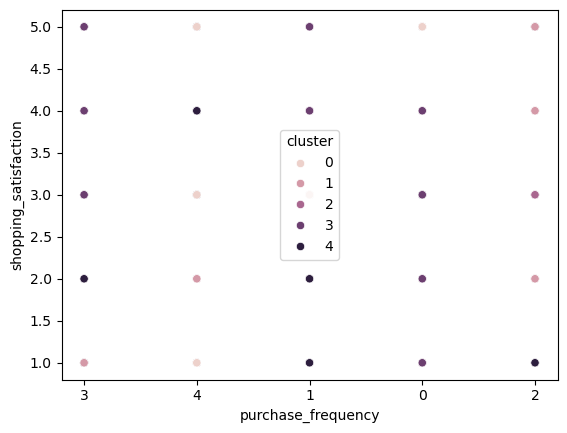

```python
sns.scatterplot(data=kdf,x='purchase_frequency',y='shopping_satisfaction',hue='cluster')
```

# Task 4: Recommendation and Review Insights

## ● Examine the relationship between recommendation helpfulness and shopping satisfaction.

[figure not shown]

```python
ax=sns.barplot(data=df,x='recommendation_helpfulness',y='shopping_satisfaction',width=0.2)
plt.xticks(rotation=45,horizontalalignment='right')
for containers in ax.containers:
    ax.bar_label(containers,fmt='%.2f',padding=16,color='red')
plt.tight_layout()
plt.title('barplot showing mean age of all the segements');
```

```python
df.recommendation_helpfulness
```

```
0            Yes
2      Sometimes
5      Sometimes
7      Sometimes
8      Sometimes
         ...
794    Sometimes
795    Sometimes
797          Yes
798    Sometimes
799    Sometimes
Name: recommendation_helpfulness, Length: 553, dtype: object
```

```python
df.columns
```

```
Index(['age', 'gender', 'purchase_frequency', 'purchase_categories',
       'browsing_frequency', 'product_search_method',
       'search_result_exploration', 'customer_reviews_importance',
       'add_to_cart_browsing', 'cart_completion_frequency',
       'cart_abandonment_factors', 'saveforlater_frequency', 'review_left',
       'review_reliability', 'review_helpfulness',
       'personalized_recommendation_frequency', 'recommendation_helpfulness',
       'rating_accuracy', 'shopping_satisfaction', 'service_appreciation',
       'improvement_areas', 'transaction', 'date', 'time', 'am_pm'],
      dtype='object')
```

```python
kdf[['recommendation_helpfulness','shopping_satisfaction']].corr()
```

|  | recommendation_helpfulness | shopping_satisfaction |
| --- | --- | --- |
| recommendation_helpfulness | 1.00000 | -0.04218 |
| shopping_satisfaction | -0.04218 | 1.00000 |

**the relationship is not a very strong one**

## Evaluate how review reliability and helpfulness impact overall ratings

```python
df[['review_reliability','review_helpfulness','rating_accuracy']]
```

|  | review_reliability | review_helpfulness | rating_accuracy |
| --- | --- | --- | --- |
| 0 | Rarely | No | 3 |
| 2 | Rarely | No | 3 |
| 5 | Occasionally | Sometimes | 4 |
| 7 | Occasionally | Sometimes | 5 |
| 8 | Never | Yes | 1 |
| ... | ... | ... | ... |
| 794 | Moderately | Sometimes | 4 |
| 795 | Rarely | Sometimes | 4 |
| 797 | Heavily | Yes | 2 |
| 798 | Occasionally | No | 4 |
| 799 | Occasionally | Sometimes | 3 |

553 rows × 3 columns

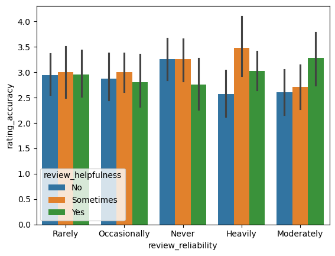

```python
sns.barplot(data=df,x='review_reliability',y='rating_accuracy',hue='review_helpfulness')
```

## Identify trends in how often customers engage with or trust personalized recommendations.

```python
df.personalized_recommendation_frequency
```

```
0      1
2      5
5      5
7      1
8      5
      ..
794    4
795    3
797    5
798    4
799    1
Name: personalized_recommendation_frequency, Length: 553, dtype: int64
```

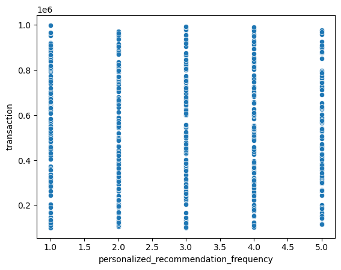

```python
sns.scatterplot(data=df, x='personalized_recommendation_frequency',y='transaction')
```

```python
kdf[['personalized_recommendation_frequency','transaction']].corr()
```

|  | personalized_recommendation_frequency | transaction |
| --- | --- | --- |
| personalized_recommendation_frequency | 1.000000 | -0.057022 |
| transaction | -0.057022 | 1.000000 |

**there is no significant relation between both the columns**

# Task 5: Visualization and Reporting

## Create attractive visualizations (bar charts, heatmaps, pie charts) for:

### Purchase categories

```python
product_count
```

|  | purchase_categories | count |
| --- | --- | --- |
| 0 | Clothing and Fashion | 334 |
| 1 | Beauty and Personal Care | 284 |
| 2 | Home and Kitchen | 284 |
| 3 | others | 277 |
| 4 | Groceries and Gourmet Food | 260 |

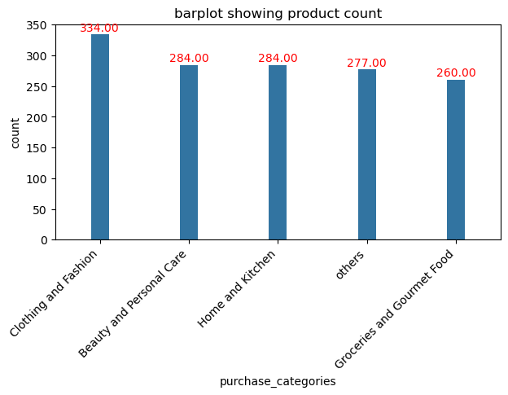

```python
ax=sns.barplot(data=product_count,x='purchase_categories',y='count',width=0.2)
plt.xticks(rotation=45,horizontalalignment='right')
for containers in ax.containers:
    ax.bar_label(containers,fmt='%.2f',padding=1,color='red')
plt.tight_layout()
plt.title('barplot showing product count');
```

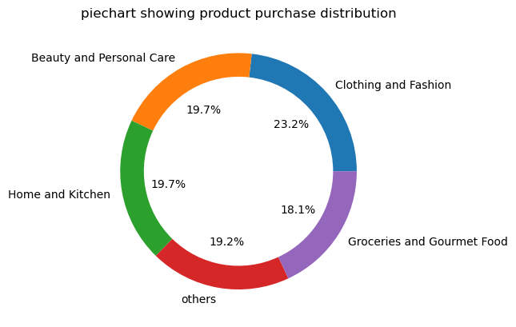

```python
plt.pie(df['purchase_categories'].str.split(';').explode().value_counts(),labels=df['purchase_categories'].str.split(';').explode().value_counts().index,autopct='%0.1f%%',wedgeprops=dict(width=0.2))
plt.title('piechart showing product purchase distribution');
```

### Browsing frequency distribution

```python
df.columns
```

```
Index(['age', 'gender', 'purchase_frequency', 'purchase_categories',
       'browsing_frequency', 'product_search_method',
       'search_result_exploration', 'customer_reviews_importance',
       'add_to_cart_browsing', 'cart_completion_frequency',
       'cart_abandonment_factors', 'saveforlater_frequency', 'review_left',
       'review_reliability', 'review_helpfulness',
       'personalized_recommendation_frequency', 'recommendation_helpfulness',
       'rating_accuracy', 'shopping_satisfaction', 'service_appreciation',
       'improvement_areas', 'transaction', 'date', 'time', 'am_pm'],
      dtype='object')
```

```python
df.browsing_frequency.unique()
```

```
array(['0', '1', '2', '3'], dtype=object)
```

**taking ['Few times a month', 'Rarely', 'Few times a week','Multiple times a day'] as 0,1,2,3**

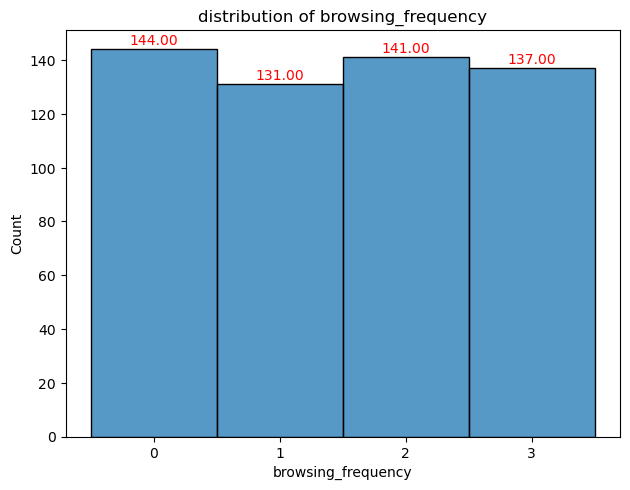

```python
ax=sns.histplot(df.browsing_frequency)
for containers in ax.containers:
    ax.bar_label(containers,fmt='%.2f',padding=1,color='red')
plt.tight_layout()
plt.title('distribution of browsing_frequency');
```

### Satisfaction levels

```python
df.shopping_satisfaction.value_counts()
```

```
shopping_satisfaction
3    124
2    114
1    114
5    105
4     96
Name: count, dtype: int64
```

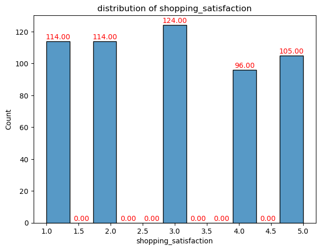

```python
ax=sns.histplot(df.shopping_satisfaction)
for containers in ax.containers:
    ax.bar_label(containers,fmt='%.2f',padding=1,color='red')
plt.tight_layout()
plt.title('distribution of shopping_satisfaction');
```

### Correlation between recommendation usefulness and satisfaction

```python
corr = kdf[['recommendation_helpfulness','shopping_satisfaction']].corr()
```

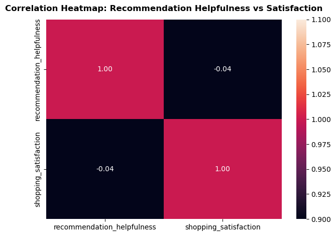

```python
sns.heatmap(corr,annot=True,vmin=1,vmax=1,fmt='.2f', cbar=True)

plt.title('Correlation Heatmap: Recommendation Helpfulness vs Satisfaction', fontweight='bold', pad=12)
plt.tight_layout()
plt.show()
```

**not a very strong relation**

# VIDEO LINK

```python
#  https://drive.google.com/file/d/1jhStbZfXAFd7zC8Of3RqJ09MhapoBGZV/view?usp=sharing
```